# **Installing and Importing Necessary Libraries and Dependencies**

```python
!pip -q install \
    langchain==1.2.10 \
    langchain-openai==1.1.10 \
    langgraph==1.0.8 \
    langsmith==0.7.3 \
    langchain-community==0.4.1 \
    langchain-huggingface==1.2.0 \
    openai==2.21.0 \
    pandas \
    numpy \
    scikit-learn==1.6.1 \
    sentence-transformers==5.2.3 \
    pydantic==2.12.3 \
    langchain-chroma \
    langchain-text-splitters \
    pypdf
```

**Note**:

- After running the above cell, kindly restart the runtime (for Google Colab) or notebook kernel (for VSCode/Jupyter Notebook), and run all cells sequentially from the next cell.
- On executing the above line of code, you might see a warning regarding package dependencies. This error message can be ignored as the above code ensures that all necessary libraries and their dependencies are maintained to successfully execute the code in **this notebook**.

```python
# Standard library - file handling, timing, database, data structures
import os
import json
import csv
import time
import sqlite3
import pandas as pd
from typing import Literal, Optional, Annotated, TypedDict
from datetime import datetime
from collections import defaultdict, Counter
from dataclasses import dataclass, fields

# Pydantic - structured output schemas and validation
from pydantic import BaseModel, Field, model_validator

# LangChain - LLM interface, message types, document objects, tool decorator
from langchain_openai import ChatOpenAI
from langchain_core.messages import SystemMessage, HumanMessage
from langchain_core.documents import Document
from langchain_core.tools import tool

# Document processing - PDF text extraction, chunking, embeddings, vector store
from langchain_text_splitters import RecursiveCharacterTextSplitter
from langchain_huggingface import HuggingFaceEmbeddings
from langchain_chroma import Chroma
from pypdf import PdfReader

# Agent orchestration - state graph, traceability
from langgraph.graph import StateGraph, END
from langsmith import traceable, Client

# Notebook display - for rendering workflow graph
from IPython.display import Image

# Suppress non-critical warnings for cleaner output
import warnings
warnings.filterwarnings("ignore")
```

## Identify environment to switch from local to google drive

```python
# Identify the environment to switch the file paths either to use Google Drive or Local
import sys
# Check if the operating system is Windows
if sys.platform.startswith('win'):
    print("Running on Windows")
    resourcePath=""
else:
    # Assume it's a Linux-based environment, likely Google Colab
    print("Running on Linux most likely Colab")
    # Mount Google Drive for Colab environments to access files
    from google.colab import drive
    drive.mount('/content/drive', force_remount=True)
    # Define the base path for resources in Google Drive
    resourcePath="/content/drive/MyDrive/ColabAssignments/LastMileDelivery/"

DEBUG_LOG = False
def debugLog(value: object) -> None:
    """Utility function to control verbose debug logging output."""
    print (value) if DEBUG_LOG else None
```

```
Running on Windows
```

# **LLM and Agent Observability Setup**

We load all OpenAI and LangSmith credentials from a secure `config.json` file and store them as environment variables.

```python
# Load the JSON file and extract values
file_name = resourcePath + 'config.json'                                        # Name of the configuration file
with open(file_name, 'r') as file:                                              # Open the config file in read mode
    config = json.load(file)                                                    # Load the JSON content as a dictionary

    OPENAI_API_KEY = config.get("OPENAI_API_KEY")                               # Extract OpenAI API key
    OPENAI_API_BASE = config.get("OPENAI_API_BASE")                             # Extract OpenAI base URL

    LANGCHAIN_TRACING_V2 = config.get("LANGCHAIN_TRACING_V2")                   # Extract LangSmith tracing flag
    LANGCHAIN_API_KEY = config.get("LANGCHAIN_API_KEY")                         # Extract LangSmith API key
    LANGCHAIN_PROJECT = config.get("LANGCHAIN_PROJECT")                         # Extract LangSmith project name

# Store OpenAI credentials in environment variables
os.environ['OPENAI_API_KEY'] = OPENAI_API_KEY                                   # Set OpenAI API key
os.environ['OPENAI_BASE_URL'] = OPENAI_API_BASE                                 # Set OpenAI API base URL

# Store LangSmith credentials in environment variables
os.environ['LANGCHAIN_TRACING_V2'] = LANGCHAIN_TRACING_V2                       # Enable LangSmith tracing
os.environ['LANGCHAIN_API_KEY'] = LANGCHAIN_API_KEY                             # Set LangSmith API key
os.environ['LANGCHAIN_PROJECT'] = LANGCHAIN_PROJECT                             # Set LangSmith project
```

```python
# Setting up the LLM for generation using a smaller model with some creativity (temperature=0.5)
gen_llm = ChatOpenAI(model="gpt-4o-mini", temperature=0.5)

# Setting up the LLM for evaluation using a more powerful model with deterministic output (temperature=0.0)
eval_llm = ChatOpenAI(model="gpt-4o", temperature=0.0)
```

# **Data Loading and Vector Database Setup**

## Loading the CSV files

```python
# Define File paths
DELIVERY_LOGS_PATH = resourcePath + "datafiles/delivery_logs.csv"                    # file path for the delivery logs CSV
CUSTOMERS_DB_PATH = resourcePath + "datafiles/customers.db"                          # file path for the customers SQLite database
PLAYBOOK_PDF_PATH = resourcePath + "datafiles/exception_resolution_playbook.pdf"     # file path for the exception playbook PDF
GROUND_TRUTH_PATH = resourcePath + "datafiles/ground_truth.csv"                      # file path for the ground truth CSV

# Loading the delivery logs CSV into a DataFrame
delivery_logs_df = pd.read_csv(DELIVERY_LOGS_PATH)
print(f"Delivery logs CSV: {len(delivery_logs_df)} rows")

# Loading the ground truth CSV into a DataFrame
ground_truth_df = pd.read_csv(GROUND_TRUTH_PATH)
print(f"Ground truth CSV: {len(ground_truth_df)} rows")
```

```
Delivery logs CSV: 13 rows
Ground truth CSV: 13 rows
```

## Loading the SQLite database

```python
# Connecting to the customers SQLite database and counting records in customers and lockers tables
conn = sqlite3.connect(CUSTOMERS_DB_PATH)
cursor = conn.cursor()

cursor.execute("SELECT COUNT(*) FROM customers")
print(f"Customers in DB: {cursor.fetchone()[0]}")

cursor.execute("SELECT COUNT(*) FROM lockers")
print(f"Lockers in DB: {cursor.fetchone()[0]}")

conn.close()
```

```
Customers in DB: 12
Lockers in DB: 6
```

## PDF Ingestion Pipeline

### Loading the PDF file

```python
# Reading the playbook PDF
reader = PdfReader(PLAYBOOK_PDF_PATH)
playbook_pages = []

# Extract all pages of the playbook, but only keep those that have actual text content (some pages may be blank or contain only images)
for i, page in enumerate(reader.pages):
    text = page.extract_text()

    # Remove pages that are blank or contain only images (no text)
    if text.strip():
        playbook_pages.append(Document(
            page_content=text,
            metadata={"source": "playbook", "page": i + 1}
        ))

print(f"Extracted {len(playbook_pages)} pages from playbook")
```

```
Extracted 10 pages from playbook
```

### Creating Vector Database

```python
# Chunking parameters
CHUNK_SIZE = 2000       # chunk size
CHUNK_OVERLAP = 200     # overlap size

# Split playbook pages into smaller chunks for embedding
text_splitter = RecursiveCharacterTextSplitter(
    chunk_size=CHUNK_SIZE,
    chunk_overlap=CHUNK_OVERLAP,
    separators=["\n\n", "\n", ". ", " "]
)

# Split the playbook pages into chunks and print the total number of chunks created
playbook_chunks = text_splitter.split_documents(playbook_pages)
print(f"{len(playbook_chunks)} chunks created from playbook")
```

```
17 chunks created from playbook
```

### Creating Embeddings

```python
# Create a HuggingFace sentence transformer embedding model for vectorization
embedding_model = HuggingFaceEmbeddings(model_name="all-MiniLM-L6-v2")
vectorstore = Chroma.from_documents(
    documents=playbook_chunks,
    embedding=embedding_model,
    collection_name="playbook"
)

# Number of chunks to retrieve per query - adjust for recall vs context length tradeoff
RETRIEVE_CHUNKS_NUM = 10    # number of chunks to fetch from the vector database

# Create a retriever that returns the most similar chunks per query
playbook_retriever = vectorstore.as_retriever(search_kwargs={"k": RETRIEVE_CHUNKS_NUM})
print("Playbook vector store ready.")
```

```
Playbook vector store ready.
```

# **Tool Definition**

Let's define the tools to be used by the multi-agent system.

## Delivery Log Reader

This tool reads all delivery log rows from the CSV file into a list of dictionaries.

```python
@tool
def read_delivery_logs() -> list[dict]:
    """Read all delivery log rows from CSV. Used by preprocessor only."""
    # Open the CSV and parse each row into a dictionary keyed by column headers
    with open(DELIVERY_LOGS_PATH, "r") as f:
        return list(csv.DictReader(f))
```

## Customer Profile Lookup

We first define a shared database connection for all tools.

```python
# Shared read-only connection for all tools
db_conn = sqlite3.connect(CUSTOMERS_DB_PATH)
db_conn.row_factory = sqlite3.Row
```

This tool fetches a customer profile from the SQLite database by customer ID.

- The `include_pii` flag controls whether the customer's name is included in the response.
- When set to `False` (default), the name field is removed before returning.
- This enforces data privacy at the tool level: only the Communication Agent requests PII for message personalization; all other agents receive the redacted profile.

```python
@tool
def lookup_customer_profile(customer_id: str, include_pii: bool = False) -> dict:
    """Fetch customer profile from SQLite. PII (name) only included when explicitly requested."""
    # Query the customer record by ID
    cursor = db_conn.cursor()
    cursor.execute("SELECT * FROM customers WHERE customer_id = ?", (customer_id,))
    row = cursor.fetchone()

    # Return empty dict if customer not found
    if row is None:
        return {}

    # Convert database row to dictionary
    profile = dict(row)

    # Redact customer name unless PII is explicitly requested
    if not include_pii:
        profile.pop("name", None)

    return profile
```

## Locker Availability Checker

This tool queries the SQLite database for lockers in the same zip code as the delivery address, then evaluates each locker's eligibility based on three constraints:

- package size must fit within the locker's maximum capacity,
- the locker cannot be full, and
- lockers with limited capacity only accept small packages.

Each locker is returned with an eligible flag and a human-readable reason explaining the decision.

```python
@tool
def check_locker_availability(zip_code: str, package_size: str) -> list[dict]:
    """Find compatible lockers in the same zip code. Returns eligibility with reasoning."""
    # Map package sizes to numeric levels for comparison
    size_hierarchy = {"SMALL": 1, "MEDIUM": 2, "LARGE": 3}
    pkg_level = size_hierarchy.get(package_size, 0)

    # Query lockers matching the delivery zip code
    cursor = db_conn.cursor()
    cursor.execute("SELECT * FROM lockers WHERE zip_code = ?", (zip_code,))
    rows = cursor.fetchall()

    results = []
    for row in rows:
        locker = dict(row)
        locker_max = size_hierarchy.get(locker["max_package_size"], 0)

        # Check constraint 1: package must fit within locker's max size
        if locker_max < pkg_level:
            locker["eligible"] = False
            locker["reason"] = f"Locker max {locker['max_package_size']} < package {package_size}"

        # Check constraint 2: locker must not be full
        elif locker["capacity_status"] == "FULL":
            locker["eligible"] = False
            locker["reason"] = "Locker is FULL"

        # Check constraint 3: limited lockers only accept small packages
        elif locker["capacity_status"] == "LIMITED" and package_size != "SMALL":
            locker["eligible"] = False
            locker["reason"] = "Locker is LIMITED - only SMALL packages accepted"

        # All constraints passed
        else:
            locker["eligible"] = True
            locker["reason"] = "Compatible"

        results.append(locker)

    return results
```

## Playbook Search

This tool searches the playbook vector store for chunks most relevant to the given query, and returns each chunk's text content along with its source page number.

- This metadata is used for document citation tracking in the evaluation output.

```python
@tool
def search_playbook(query: str) -> list[dict]:
    """Retrieve relevant playbook sections via vector search. Returns chunks with page metadata."""
    # Run similarity search against the ChromaDB vector store
    docs = playbook_retriever.invoke(query)

    # Return chunk content and page number for each retrieved document
    return [
        {"content": d.page_content, "page": d.metadata.get("page", "?")}
        for d in docs
    ]
```

## Escalation Rule Engine

This tool defines a fully deterministic escalation rule engine that evaluates hard-coded business rules without any LLM involvement.

It checks two categories of triggers:

- automatic triggers (third delivery attempt, VIP with high exception history, damaged perishables, perishable weather delays exceeding 4 hours, fraud-indicating addresses), and
- discretionary triggers (standard customers with unusually high exception counts, premium perishable weather delays).

Delay hours are parsed from free-text descriptions using regex to handle varied formats like "5hr", "5 hours", or "5.5hr".

```python
@tool
def check_escalation_rules(customer_tier: str, exceptions_last_90d: int,
                            attempt_number: int, package_type: str,
                            status_code: str, status_description: str) -> dict:
    """Deterministic escalation rule engine. Evaluates hard-coded business rules."""
    import re
    triggers = []

    # --- Automatic triggers ---

    # 3rd failed attempt triggers escalation regardless of customer tier
    if attempt_number >= 3:
        triggers.append("AUTOMATIC: 3rd failed delivery attempt")

    # VIP customers with 3+ exceptions in last 90 days
    if customer_tier == "VIP" and exceptions_last_90d >= 3:
        triggers.append(f"AUTOMATIC: VIP customer with {exceptions_last_90d} exceptions in 90d (>=3)")

    # Any damaged perishable package needs fast replacement decision
    if status_code == "DAMAGED" and package_type == "PERISHABLE":
        triggers.append("AUTOMATIC: Damaged perishable package")

    # Perishable with weather delay over 4 hours - item likely compromised
    if status_code == "WEATHER_DELAY" and package_type == "PERISHABLE":
        # Extract delay hours from free-text using regex (handles "5hr", "5 hours", "5.5hr")
        hour_matches = re.findall(r'(\d+(?:\.\d+)?)\s*(?:hr|hour|hours)', status_description.lower())
        if hour_matches:
            hours = float(hour_matches[0])
            if hours > 4:
                triggers.append(f"AUTOMATIC: Perishable with {hours}hr delay (>4hr threshold)")

    # Address issues suggesting potential fraud
    fraud_keywords = ["vacant", "demolished", "construction site", "empty lot"]
    if status_code == "ADDRESS_ISSUE" and any(kw in status_description.lower() for kw in fraud_keywords):
        triggers.append("AUTOMATIC: Potential fraud - address is vacant/demolished")

    # --- Discretionary triggers ---

    # Standard customer with unusually high exception count signals systemic issue
    if customer_tier == "STANDARD" and exceptions_last_90d > 5:
        triggers.append(f"DISCRETIONARY: Standard customer with {exceptions_last_90d} exceptions in 90d (>5)")

    # Premium customer with perishable in weather delay - borderline urgency
    if customer_tier == "PREMIUM" and package_type == "PERISHABLE" and status_code == "WEATHER_DELAY":
        triggers.append("DISCRETIONARY: Premium customer with perishable in weather delay")

    return {
        "has_triggers": len(triggers) > 0,                                       # Quick boolean check for any triggers
        "trigger_count": len(triggers),                                          # Total number of triggers found
        "triggers": triggers                                                     # Detailed list of trigger descriptions
    }
```

# **Multi-Agent Architecture**

Now, let's define the multi-agent system architecture.

## Multi-Agent System State and Sub-agent View

We start by defining the multi-agent state and agent view system.

- `UnifiedAgentState` carries all data through the LangGraph pipeline - every field across all agents lives here.
- To enforce data isolation, five typed view dataclasses define which fields each agent can read and write.
- The `project_into` utility function extracts only the fields in an agent's view from the global state.
- The `merge_back` utility function writes back only the fields that the agent is allowed to modify.

This ensures agents cannot access or overwrite data outside their designated scope.

```python
class UnifiedAgentState(TypedDict):
    """State object passed through the LangGraph pipeline."""
    # Input
    raw_rows: list[dict]                       # Raw delivery log rows for this shipment
    shipment_id: str

    # Preprocessor output
    consolidated_event: dict                   # Deduplicated, consolidated event
    customer_profile: dict                     # Redacted profile for resolution
    customer_profile_full: dict                # Full profile with PII for communication
    locker_availability: list[dict]            # Lockers in same zip
    playbook_context: list[dict]               # Retrieved playbook chunks with page metadata
    escalation_signals: dict                   # Deterministic rule output
    noise_override: bool                       # Preprocessor guardrail flag for routine noise
    guardrail_triggered: bool                  # True if input injection detected

    # Resolution Agent output
    resolution_output: dict                    # {is_exception, resolution, rationale}

    # Critic - resolution validation
    critic_resolution_output: dict             # {decision, rationale}
    resolution_revision_count: int             # Track retries, max 2
    critic_feedback: str                       # Feedback for revision loop

    # Communication Agent output
    communication_output: dict                 # {tone_label, communication_message}

    # Critic - communication validation
    critic_communication_output: dict          # {decision, rationale}

    # Routing
    next_agent: str                            # Next node to route to
    max_loops: int                             # Max revision loops

    # Final
    escalated: bool                            # Whether any critic node returned ESCALATE
    tool_calls_log: list[str]                  # Log of all tool invocations
    trajectory_log: list[str]                  # Audit trail of agent decisions
    start_time: Optional[float]                # Pipeline start timestamp
    latency_sec: Optional[float]               # Total pipeline latency
    final_actions: list[dict]                  # Final packaged output
```

```python
@dataclass
class RouterView:
    """Fields accessible to the Router Agent (preprocessor, orchestrator, finalize)."""
    raw_rows: list[dict]                    # Raw delivery log rows for this shipment
    shipment_id: str                        # Shipment ID for routing and context
    consolidated_event: dict                # Deduplicated, consolidated event
    customer_profile: dict                  # Redacted profile for resolution
    customer_profile_full: dict             # Full profile with PII for communication
    locker_availability: list[dict]         # Lockers in same zip
    playbook_context: list[dict]            # Retrieved playbook chunks with page metadata
    escalation_signals: dict                # Deterministic rule output
    noise_override: bool                    # Preprocessor guardrail flag for routine noise
    guardrail_triggered: bool               # True if input injection detected
    resolution_output: dict                 # {is_exception, resolution, rationale}
    critic_resolution_output: dict          # {decision, rationale}
    resolution_revision_count: int          # Track retries, max 2
    critic_feedback: str                    # Feedback for revision loop
    communication_output: dict              # {tone_label, communication_message}
    critic_communication_output: dict       # {decision, rationale}
    next_agent: str                         # Next node to route to
    max_loops: int                          # Max revision loops
    escalated: bool                         # Whether any critic node returned ESCALATE
    tool_calls_log: list[str]               # Log of all tool invocations
    trajectory_log: list[str]               # Audit trail of agent decisions
    start_time: Optional[float]             # Pipeline start timestamp
    latency_sec: Optional[float]            # Total pipeline latency
    final_actions: list[dict]               # Final packaged output
```

```python
@dataclass
class ResolutionAgentView:
    """Fields accessible to the Resolution Agent. No PII."""
    consolidated_event: dict
    customer_profile: dict                      # Redacted - no name
    locker_availability: list[dict]
    playbook_context: list[dict]
    escalation_signals: dict
    critic_feedback: str
    # Outputs owned by this agent
    resolution_output: dict
```

```python
@dataclass
class CommunicationAgentView:
    """Fields accessible to the Communication Agent. Includes PII for personalization."""
    consolidated_event: dict
    customer_profile_full: dict                  # Includes name - only agent with PII access
    locker_availability: list[dict]
    resolution_output: dict
    # Outputs owned by this agent
    communication_output: dict
```

```python
@dataclass
class CriticResolutionView:
    """Fields accessible to the Critic Agent for resolution validation. No PII."""
    consolidated_event: dict
    customer_profile: dict                       # Redacted - no name
    locker_availability: list[dict]
    playbook_context: list[dict]
    escalation_signals: dict
    resolution_output: dict
    # Outputs owned by this agent
    critic_resolution_output: dict
```

```python
@dataclass
class CriticCommunicationView:
    """Fields accessible to the Critic Agent for communication validation. No PII."""
    consolidated_event: dict
    customer_profile: dict                        # Redacted - no name
    resolution_output: dict
    communication_output: dict
    # Outputs owned by this agent
    critic_communication_output: dict
```

```python
def project_into(state: UnifiedAgentState, view_class: type) -> dict:
    """Extract only the fields defined in the agent's view from the global state."""
    # Get the set of field names from the view dataclass
    view_fields = {f.name for f in fields(view_class)}

    # Return a filtered dict containing only the fields this agent is allowed to see
    return {k: state.get(k) for k in view_fields if k in state}
```

```python
def merge_back(state: UnifiedAgentState, agent_output: dict, view_class: type) -> UnifiedAgentState:
    """Write back only the fields owned by the agent's view into the global state."""
    # Get the set of field names this agent is allowed to write
    view_fields = {f.name for f in fields(view_class)}

    # Only update state for keys that belong to this agent's view
    for k, v in agent_output.items():
        if k in view_fields:
            state[k] = v

    return state
```

## Router Agent

We first define input sanitization and preprocessing helper funbctions.

```python
# List of keywords/phrases to check for in input as simple prompt injection guardrail
INJECTION_KEYWORDS = [
    r"ignore (all |previous |prior )?(instructions|prompts|rules)",
    r"you are now|pretend (you are|to be)|act as (if you are|a)",
    r"system prompt|reveal (your|the) (prompt|instructions|system)",
    r"jailbreak|dan mode|developer mode|unrestricted mode",
    r"forget (everything|all|prior|previous)",
    r"disregard (all |your |previous )?(instructions|rules|guidelines)",
    r"new persona|override (your|all) (rules|instructions|safety)",
    r"\[system\]|<\|system\|>|##SYSTEM|\{\{system\}\}",
    r"print (your|the) (instructions|prompt|system message)",
    r"bypass (safety|content|filter|restriction)",
]
```

```python
# Simple function to check for prompt injection keywords in the input text
def scan_for_injection(text: str) -> bool:
    """Returns True if prompt injection keywords are detected in the text."""
    if not text or not isinstance(text, str):
        return False
    text_lower = text.lower()
    return any(keyword in text_lower for keyword in INJECTION_KEYWORDS)
```

```python
# Function to remove duplicate scan events from the raw delivery log rows
def deduplicate_rows(raw_rows: list[dict]) -> list[dict]:
    """Remove duplicate scan events."""
    return [r for r in raw_rows if r.get("is_duplicate_scan", "False") != "True"]
```

```python
# Function to consolidate multi-row shipment into a single event using highest attempt number and collect driver notes from all attempts
def consolidate_event(unique_rows: list[dict], raw_rows: list[dict]) -> dict:
    """Consolidate multi-row shipment into a single event using highest attempt number."""
    if unique_rows:
        primary = max(unique_rows, key=lambda r: int(r.get("attempt_number", 0)))
    else:
        primary = raw_rows[0]

    # NEW: Collect driver notes from all prior attempts
    prior_notes = [
        f"Attempt {r['attempt_number']}: {r['status_description']}"
        for r in unique_rows
        if r is not primary
    ]

    return {
        "shipment_id": primary["shipment_id"],
        "timestamp": primary["timestamp"],
        "status_code": primary["status_code"],
        "status_description": primary["status_description"],
        "customer_id": primary["customer_id"],
        "delivery_address": primary["delivery_address"],
        "package_type": primary["package_type"],
        "package_size": primary["package_size"],
        "attempt_number": int(primary["attempt_number"]),
        "prior_attempt_notes": prior_notes,
        "total_rows": len(raw_rows),
        "duplicates_removed": len(raw_rows) - len(unique_rows)
    }
```

```python
# Function to scan all free-text fields in delivery data for prompt injection
def scan_inputs_for_injection(consolidated: dict, raw_rows: list[dict]) -> bool:
    """Scan all free-text fields in delivery data for prompt injection."""
    texts = [consolidated["status_description"]]
    texts.extend(row.get("status_description", "") for row in raw_rows)
    return any(scan_for_injection(text) for text in texts)
```

```python
# Function to scan retrieved RAG chunks for prompt injection
def scan_chunks_for_injection(playbook_context: list[dict]) -> bool:
    """Scan retrieved RAG chunks for prompt injection."""
    return any(scan_for_injection(chunk.get("content", "")) for chunk in playbook_context)
```

```python
# Function to fetch all context via tools: customer profiles, lockers, playbook, escalation rules.
def fetch_context(consolidated: dict, tool_log: list[str]) -> dict:
    """Fetch all context via tools: customer profiles, lockers, playbook, escalation rules."""
    customer_id = consolidated["customer_id"]

    customer_profile = lookup_customer_profile.invoke(
        {"customer_id": customer_id, "include_pii": False}
    )
    tool_log.append(f"TOOL: lookup_customer_profile({customer_id}, pii=False)")

    customer_profile_full = lookup_customer_profile.invoke(
        {"customer_id": customer_id, "include_pii": True}
    )
    tool_log.append(f"TOOL: lookup_customer_profile({customer_id}, pii=True)")

    address_parts = consolidated["delivery_address"].split(",")
    zip_code = address_parts[-1].strip() if address_parts else ""
    locker_availability = check_locker_availability.invoke(
        {"zip_code": zip_code, "package_size": consolidated["package_size"]}
    )
    tool_log.append(f"TOOL: check_locker_availability({zip_code}, {consolidated['package_size']})")

    query = f"{consolidated['status_code']} {consolidated['package_type']} {consolidated['status_description'][:100]}"
    playbook_context = search_playbook.invoke({"query": query})
    tool_log.append("TOOL: search_playbook(query)")

    escalation_signals = check_escalation_rules.invoke({
        "customer_tier": customer_profile.get("tier", "STANDARD"),
        "exceptions_last_90d": customer_profile.get("exceptions_last_90d", 0),
        "attempt_number": consolidated["attempt_number"],
        "package_type": consolidated["package_type"],
        "status_code": consolidated["status_code"],
        "status_description": consolidated["status_description"]
    })
    tool_log.append("TOOL: check_escalation_rules(...)")

    return {
        "customer_profile": customer_profile,
        "customer_profile_full": customer_profile_full,
        "locker_availability": locker_availability,
        "playbook_context": playbook_context,
        "escalation_signals": escalation_signals
    }
```

```python
# Function to flag routine status codes with no anomaly indicators as noise override
def check_noise_override(consolidated: dict) -> bool:
    """Flag routine status codes with no anomaly indicators."""
    routine_codes = {"DELIVERED", "IN_TRANSIT", "OUT_FOR_DELIVERY", "SCANNED"}
    if consolidated["status_code"] not in routine_codes:
        return False

    anomaly_indicators = [
        "damage", "wrong", "suspicious", "overdue", "missing",
        "unexpected", "misroute", "lost", "stolen", "abandoned",
        "leak", "crush", "broke", "delay", "late", "fraud"
    ]
    desc = consolidated["status_description"].lower()
    return not any(indicator in desc for indicator in anomaly_indicators)
```

The preprocessor is the first node in the pipeline. It runs a six-step sequence:

- deduplicate scan events,
- consolidate multi-row shipments,
- scan inputs for prompt injection,
- check for routine noise (skipping tool calls if detected),
- fetch context via tools, and
- scan retrieved RAG chunks for injection.

Early returns on guardrail triggers or noise detection prevent unnecessary LLM calls and tool invocations.

```python
@traceable(name="preprocessor_node")
def preprocessor_node(state: UnifiedAgentState) -> UnifiedAgentState:
    """Deduplicates, consolidates, assembles context, and runs input guardrails."""
    # Read full state - preprocessor has RouterView (full access)
    view = project_into(state, RouterView)
    tool_log = []
    trajectory = []
    start = time.time()

    # Step 1: Remove duplicate scan events
    unique_rows = deduplicate_rows(view["raw_rows"])
    tool_log.append("PREPROCESSOR: Deduplicated rows")
    trajectory.append(f"preprocessor: {len(view['raw_rows'])} raw rows -> {len(unique_rows)} after dedup")

    # Step 2: Merge multi-row shipments into a single consolidated event
    consolidated = consolidate_event(unique_rows, view["raw_rows"])

    # Step 3: Scan driver notes for prompt injection - block before any LLM call
    if scan_inputs_for_injection(consolidated, view["raw_rows"]):
        tool_log.append("GUARDRAIL: Injection detected in delivery input")
        trajectory.append("preprocessor: Guardrail triggered - prompt injection detected")
        output = {
            "consolidated_event": consolidated,
            "customer_profile": {}, "customer_profile_full": {},
            "locker_availability": [], "playbook_context": [], "escalation_signals": {},
            "tool_calls_log": tool_log, "trajectory_log": trajectory,
            "resolution_revision_count": 0, "critic_feedback": "",
            "noise_override": False, "guardrail_triggered": True,
            "escalated": True, "start_time": start, "next_agent": "finalize"
        }
        return merge_back(state, output, RouterView)

    # Step 4: Check for routine noise before making any tool calls
    noise_override = check_noise_override(consolidated)
    if noise_override:
        tool_log.append("PREPROCESSOR: Noise guardrail - routine status with no anomaly")
        trajectory.append(f"preprocessor: {consolidated['status_code']} flagged as noise by guardrail, skipping tool calls")
        output = {
            "consolidated_event": consolidated,
            "customer_profile": {}, "customer_profile_full": {},
            "locker_availability": [], "playbook_context": [],
            "escalation_signals": {},
            "tool_calls_log": tool_log, "trajectory_log": trajectory,
            "resolution_revision_count": 0, "critic_feedback": "",
            "noise_override": True, "guardrail_triggered": False,
            "escalated": False, "start_time": start, "next_agent": "orchestrator"
        }
        return merge_back(state, output, RouterView)

    # Step 5: Fetch context via tools (only for non-noise cases)
    context = fetch_context(consolidated, tool_log)

    # Step 6: Scan retrieved playbook chunks for injection
    if scan_chunks_for_injection(context["playbook_context"]):
        tool_log.append("GUARDRAIL: Injection detected in retrieved playbook chunk")
        trajectory.append("preprocessor: Guardrail triggered - injection in RAG chunk")
        context["playbook_context"] = []                                         # Drop contaminated chunks
        output = {
            "consolidated_event": consolidated,
            **context,
            "tool_calls_log": tool_log, "trajectory_log": trajectory,
            "resolution_revision_count": 0, "critic_feedback": "",
            "noise_override": False, "guardrail_triggered": True,
            "escalated": True, "start_time": start, "next_agent": "finalize"
        }
        return merge_back(state, output, RouterView)

    # Package all context and pass to orchestrator
    output = {
        "consolidated_event": consolidated,
        **context,
        "tool_calls_log": tool_log, "trajectory_log": trajectory,
        "resolution_revision_count": 0, "critic_feedback": "",
        "noise_override": noise_override, "guardrail_triggered": False,
        "escalated": False, "start_time": start, "next_agent": "orchestrator"
    }
    return merge_back(state, output, RouterView)
```

The orchestrator is a deterministic routing node invoked after every agent completes.

- It reads the current pipeline state and decides the next step in a fixed priority sequence:
  - guardrail-blocked cases go to finalize immediately,
  - noise cases bypass the LLM,
  - exception cases flow through the full Resolution → Critic → Communication → Critic → finalize path, with revision loops capped at 2 retries.

Automatic escalation triggers from the rule engine are enforced here, and they cannot be overridden by LLM judgment.

```python
@traceable(name="orchestrator_node")
def orchestrator_node(state: UnifiedAgentState) -> UnifiedAgentState:
    """
    Central router. Determines next_agent based on current state.

    Routing order:
      0. Guardrail triggered                          -> finalize
      1. Noise override from preprocessor             -> finalize (skip LLM)
      2. Resolution not yet run                       -> resolution_agent
      3. Resolution done, critic not yet run          -> critic_resolution
      4. Critic returned REVISE and under loop limit  -> resolution_agent (reset)
      5. Critic returned REVISE and at loop limit     -> force ESCALATE -> communication/finalize
      6. Enforce automatic escalation triggers         (rule engine is authoritative)
      7. Not an exception                             -> finalize
      8. Communication not yet run                    -> communication_agent
      9. Communication done, critic not yet run       -> critic_communication
      10. All done                                    -> finalize
    """
    # Read state through router view
    view = project_into(state, RouterView)

    # 0. Guardrail triggered - no LLM, force escalation, go to finalize
    if view.get("guardrail_triggered"):
        state["resolution_output"] = {
            "is_exception": "YES",
            "resolution": "RESCHEDULE",
            "rationale": "Input flagged by guardrail - prompt injection detected. Defaulting to RESCHEDULE with forced escalation for human review."
        }
        state["escalated"] = True
        state["next_agent"] = "finalize"
        state["trajectory_log"].append("orchestrator: Guardrail triggered, forcing escalation to finalize")
        return state

    # 1. Noise override - classify as non-exception, skip all agents
    if view.get("noise_override") and not view.get("resolution_output"):
        state["resolution_output"] = {
            "is_exception": "NO",
            "resolution": "N/A",
            "rationale": f"Status code {view['consolidated_event']['status_code']} with routine description. No anomaly indicators. Classified as noise by preprocessor guardrail."
        }
        state["trajectory_log"].append("orchestrator: Noise override from preprocessor, skipping to finalize")
        state["next_agent"] = "finalize"
        return state

    # 2. Resolution Agent hasn't run yet - send it there
    if not view.get("resolution_output"):
        state["next_agent"] = "resolution_agent"
        return state

    # 3. Resolution done but Critic hasn't validated yet
    if not view.get("critic_resolution_output"):
        state["next_agent"] = "critic_resolution"
        return state

    critic_decision = view["critic_resolution_output"].get("decision")

    # 4. Critic wants a revision and we're under the retry limit
    if critic_decision == "REVISE" and view["resolution_revision_count"] < view["max_loops"]:
        state["resolution_output"] = {}                                          # Clear for retry
        state["critic_resolution_output"] = {}                                   # Clear for retry
        state["next_agent"] = "resolution_agent"
        state["trajectory_log"].append(
            f"orchestrator: REVISE loop {view['resolution_revision_count']}/{view['max_loops']}"
        )
        return state

    # 5. Revision limit exhausted - force escalate, still generate communication if exception
    if critic_decision == "REVISE" and view["resolution_revision_count"] >= view["max_loops"]:
        state["escalated"] = True
        state["critic_resolution_output"] = {
            "decision": "ESCALATE",
            "rationale": "Max revision loops reached. Accepting current resolution with escalation."
        }
        if view["resolution_output"].get("is_exception") == "YES":
            state["next_agent"] = "communication_agent"                          # Still notify customer
        else:
            state["next_agent"] = "finalize"
        state["trajectory_log"].append("orchestrator: Max loops reached, forcing ESCALATE")
        return state

    # 6. Enforce automatic escalation triggers - rule engine is authoritative
    if view.get("escalation_signals", {}).get("has_triggers"):
        automatic = [t for t in view["escalation_signals"].get("triggers", [])
                     if t.startswith("AUTOMATIC")]
        if automatic and view["resolution_output"].get("is_exception") == "YES":
            state["escalated"] = True
            state["trajectory_log"].append(
                f"orchestrator: Forced escalation from rule engine - {automatic}"
            )

    # 7. Not an exception - no customer message needed, go to finalize
    if view["resolution_output"].get("is_exception") == "NO":
        state["next_agent"] = "finalize"
        state["trajectory_log"].append("orchestrator: Not an exception, skipping to finalize")
        return state

    # 8. Communication Agent hasn't run yet
    if not view.get("communication_output"):
        state["next_agent"] = "communication_agent"
        return state

    # 9. Communication done but Critic hasn't validated yet
    if not view.get("critic_communication_output"):
        state["next_agent"] = "critic_communication"
        return state

    # 10. Everything complete - finalize
    state["next_agent"] = "finalize"
    return state
```

This is the final node in the pipeline.

- It packages all results into a structured output dict, computes end-to-end latency, and logs the final action to the trajectory.
- Guardrail-blocked cases produce a distinct output with `guardrail_blocked: True` so evaluation can handle them separately.

```python
@traceable(name="finalize_node")
def finalize_node(state: UnifiedAgentState) -> UnifiedAgentState:
    """Packages final results and records end time."""
    # Read state through router view
    view = project_into(state, RouterView)

    # Guardrail-blocked cases get a distinct safe output
    if view.get("guardrail_triggered"):
        final = {
            "shipment_id": view["shipment_id"],
            "is_exception": "BLOCKED",
            "resolution": "ESCALATED",
            "escalated": True,
            "tone": "N/A",
            "message": "This shipment was flagged by the input guardrail and requires human review.",
            "revision_count": 0,
            "guardrail_blocked": True
        }
    else:
        # Normal case - package predictions from all agents
        final = {
            "shipment_id": view["shipment_id"],
            "is_exception": view.get("resolution_output", {}).get("is_exception", "ERROR"),
            "resolution": view.get("resolution_output", {}).get("resolution", "ERROR"),
            "escalated": view["escalated"],
            "tone": view.get("communication_output", {}).get("tone_label", "N/A"),
            "message": view.get("communication_output", {}).get("communication_message", ""),
            "revision_count": view["resolution_revision_count"],
            "guardrail_blocked": False
        }

    # Compute total pipeline latency
    latency = time.time() - view["start_time"] if view.get("start_time") else 0.0

    # Write final output back to state
    output = {
        "final_actions": [final],
        "latency_sec": latency,
        "next_agent": "END",
    }

    # Log the final action and latency to the audit trail
    state["trajectory_log"].append(
        f"finalize: actions={json.dumps(final)}; latency={latency:.3f}s"
    )

    return merge_back(state, output, RouterView)
```

## Resolution Agent

We first define the output schema for the Resolution Agent.

- A Pydantic model validator enforces mutual consistency between is_exception and resolution.
- If the LLM produces a contradictory pair (e.g., `exception="YES"` with `resolution="N/A"`), the validation fails and the structured output call retries.

```python
class ResolutionOutput(BaseModel):
    """Resolution Agent output schema."""
    # Whether this delivery event requires action
    is_exception: Literal["YES", "NO"] = Field(
        description="Whether this delivery event is a real actionable exception"
    )
    # What action to take - must be N/A when not an exception
    resolution: Literal[
        "RESCHEDULE", "REROUTE_TO_LOCKER", "REPLACE", "RETURN_TO_SENDER", "N/A"
    ] = Field(
        description="Resolution action. N/A if is_exception is NO"
    )
    # Explanation of the decision for auditability
    rationale: str = Field(
        description="Step-by-step reasoning for the classification and resolution decision"
    )

    @model_validator(mode="after")
    def validate_consistency(self):
        """Enforce that is_exception and resolution are mutually consistent."""
        if self.is_exception == "YES" and self.resolution == "N/A":
            raise ValueError("resolution cannot be N/A when is_exception is YES")
        if self.is_exception == "NO" and self.resolution != "N/A":
            raise ValueError("resolution must be N/A when is_exception is NO")
        return self
```

Next, we define the Resolution Agent's system prompt

- It should contain at least the role, rules, and guidelines to direct the LLM regarding the task at hand.

```python
RESOLUTION_AGENT_SYSTEM_PROMPT = """
You are an expert AI Resolution Agent for last-mile logistics. Your goal is to resolve delivery exceptions
proactively, reducing redelivery costs and preventing customer churn.

Operational Guidelines:
Analyze Exception: Identify the root cause (e.g., incorrect address, no one home, damaged).

Execute Resolution Strategy:
Address Mismatch: Use tool validate_address and update_delivery_instructions.
Failed Attempt/No One Home: Offer scheduling a new 2-hour window or redirect to a local pickup locker.
Damaged Package: Initiate 'reship' or 'process refund' instantly if severity is high.
Weather/Delay: Update Estimated Time of Arrival (ETA) in real-time.
Minimize Cost: Choose the option that balances customer satisfaction with the lowest re-attempt cost.
Escalate: If the customer is hostile or after 3 failed attempts, escalate to a human agent.
You are proactive, logical, and focused on saving the shipment.

{critic_feedback}"""
```

Next, we define a helper function that formats retrieved playbook chunks into a single string with page references.

```python
# Communication Agent system prompt with instructions for tone and content based on customer profile and resolution outcome.
def format_playbook_context(playbook: list[dict]) -> str:
    """Format playbook chunks with page references for LLM context."""
    # Combine all chunks with page labels and separator lines
    return "\n\n---\n\n".join(
        [f"[Page {c['page']}] {c['content']}" for c in playbook]
    )
```

Finally, we define the Resolution Agent node. It

- projects the state into `ResolutionAgentView` (no PII access),
- builds the LLM prompt with all context and any prior Critic feedback, and
- invokes the LLM with structured output.

If the Pydantic validator rejects the output (e.g., contradictory is_exception/resolution pair), the call retries up to defined number of times.

If all retries fail, it defaults to `RESCHEDULE` with forced escalation for human review.

Only the `resolution_output` field is written back to state.

```python
@traceable(name="resolution_agent_node")
def resolution_agent_node(state: UnifiedAgentState) -> UnifiedAgentState:
    """Resolution Agent: classifies exception and decides resolution action."""
    # Read only fields this agent is allowed to see - no PII, no communication data
    view = project_into(state, ResolutionAgentView)

    # If this is a revision attempt, append the Critic's feedback to the prompt
    feedback = view.get("critic_feedback", "")
    feedback_section = ""
    if feedback:
        feedback_section = (
            f"\n\nPREVIOUS ATTEMPT WAS REJECTED. Critic feedback:\n{feedback}\n"
            f"Revise your decision based on this feedback."
        )

    # Build the system prompt with optional feedback section
    system_prompt = RESOLUTION_AGENT_SYSTEM_PROMPT.format(critic_feedback=feedback_section)

    # Format playbook chunks with page references
    playbook_text = format_playbook_context(view["playbook_context"])

    # Assemble all context into the user message
    user_content = (
        f"DELIVERY EVENT:\n{json.dumps(view['consolidated_event'], indent=2)}\n\n"
        f"CUSTOMER PROFILE (redacted):\n{json.dumps(view['customer_profile'], indent=2)}\n\n"
        f"LOCKER AVAILABILITY:\n{json.dumps(view['locker_availability'], indent=2)}\n\n"
        f"ESCALATION SIGNALS:\n{json.dumps(view['escalation_signals'], indent=2)}\n\n"
        f"RELEVANT PLAYBOOK SECTIONS:\n{playbook_text}"
    )

    # Invoke LLM with Pydantic-enforced structured output
    structured_llm = gen_llm.with_structured_output(ResolutionOutput)
    max_retries = 3    # number of retries
    result = None

    for attempt in range(max_retries):
        try:
            result = structured_llm.invoke([
                SystemMessage(content=system_prompt),
                HumanMessage(content=user_content)
            ])
            break                                                                # Valid output, exit retry loop
        except Exception as e:
            if attempt < max_retries - 1:
                # Log the failure and retry
                state["trajectory_log"].append(
                    f"resolution_agent: Validation failed (attempt {attempt + 1}), retrying - {str(e)[:100]}"
                )
            else:
                # All retries exhausted - safe fallback with forced escalation
                result = ResolutionOutput(
                    is_exception="YES",
                    resolution="RESCHEDULE",
                    rationale=(
                        f"Resolution agent failed after {max_retries} attempts. "
                        f"Defaulting to RESCHEDULE with escalation. Last error: {str(e)[:200]}"
                    )
                )
                state["escalated"] = True
                state["trajectory_log"].append(
                    f"resolution_agent: All {max_retries} retries exhausted, "
                    f"defaulting to RESCHEDULE with forced escalation"
                )

    # Write back only the field this agent owns
    agent_output = {
        "resolution_output": result.model_dump()
    }
    state = merge_back(state, agent_output, ResolutionAgentView)

    # Log the invocation and decision to shared audit trails
    state["tool_calls_log"].append("AGENT: resolution_agent invoked")
    state["trajectory_log"].append(
        f"resolution_agent: is_exception={result.is_exception}, resolution={result.resolution}"
    )
    state["next_agent"] = "orchestrator"
    return state
```

## Communication Agent

We first define the output schema for the Communication Agent.

- Two required fields: tone label and the customer message.
- No model validator needed here since both fields are always required and have no cross-field dependencies.

```python
# Communication Agent system prompt with instructions for tone and content based on customer profile and resolution outcome.
class CommunicationOutput(BaseModel):
    """Communication Agent output schema."""
    # Tone inferred from customer tier: VIP/PREMIUM -> FORMAL, STANDARD -> CASUAL
    tone_label: Literal["FORMAL", "CASUAL"] = Field(
        description="Tone of the customer message, inferred from customer tier"
    )
    # The actual notification text sent to the customer
    communication_message: str = Field(
        description="The customer-facing notification message"
    )
```

Next, we define the Communication Agent's system prompt.

- It should contain at least the role, rules, and guidelines to direct the LLM regarding the task at hand.

```python
COMMUNICATION_AGENT_SYSTEM_PROMPT = """
You are an empathetic, professional Customer Communication Agent for a last-mile delivery team.
Your goal is to inform customers about delivery exceptions transparently and turn a negative experience
into a positive one.

Tone: Empathetic, calm, proactive, and clear.

Operational Guidelines:
Proactive Alerts: Notify customers immediately when a delivery exception is triggered (weather, delay, address issue).
Clear Messaging: Explain why the delay happened (e.g., 'incorrect address' or 'weather delay').
Actionable Solutions: Provide clear, simple options for the customer (e.g., 'Click here to update your address', 'Reschedule for tomorrow', or 'Hold at pickup location').
Empathy First: Acknowledge frustration: 'I apologize for the delay. I know you're expecting this...'.

Avoid technical jargon. Keep messages concise and action-oriented.
"""
```

Next, we define a helper function that builds the context dictionary and locker info string from the Communication Agent's view.

- Extracts only the fields needed for message generation - customer name, tier, channel, credit, exception details, and resolution.
- If the resolution is a locker reroute, includes the first eligible locker's details for the notification.

```python
# Function to build the context dict and locker info string for the Communication Agent,
# using only fields available in CommunicationAgentView.
def build_communication_context(view: dict) -> tuple[dict, str]:
    """Build the context dict and locker info string for the Communication Agent.
    Only uses fields available in CommunicationAgentView."""
    event = view["consolidated_event"]
    profile = view["customer_profile_full"]
    resolution = view["resolution_output"]
    lockers = view["locker_availability"]

    # Include locker details only if the resolution is a reroute
    locker_info = ""
    if resolution.get("resolution") == "REROUTE_TO_LOCKER":
        eligible = [l for l in lockers if l.get("eligible")]
        if eligible:
            locker_info = f"\nLOCKER FOR REROUTE:\n{json.dumps(eligible[0], indent=2)}"

    # Assemble the context the LLM needs for message generation
    comm_context = {
        "customer_name": profile.get("name", "Customer"),
        "customer_tier": profile.get("tier"),
        "preferred_channel": profile.get("preferred_channel"),
        "active_credit": profile.get("active_credit", 0),
        "exception_type": event["status_code"],
        "status_description": event["status_description"],
        "package_type": event["package_type"],
        "resolution": resolution.get("resolution"),
        "resolution_rationale": resolution.get("rationale")
    }

    return comm_context, locker_info
```

Finally, we define the Communication Agent node. It is the only agent with PII access (customer name). It

- projects the state into `CommunicationAgentView`,
- builds the message context, and
- invokes the LLM with structured output.

It includes a retry loop with a safe fallback: if the LLM fails after the defined number of attempts, it generates a generic message with the correct tone and forces escalation for human follow-up.

Only the `communication_output` field is written back to state.

```python
@traceable(name="communication_agent_node")
def communication_agent_node(state: UnifiedAgentState) -> UnifiedAgentState:
    """Communication Agent: generates customer notification. Only agent with PII access."""
    # Read from communication view - includes customer name for personalization
    view = project_into(state, CommunicationAgentView)

    # Build the context and locker info from the projected view
    comm_context, locker_info = build_communication_context(view)

    # Assemble the user message for the LLM
    user_content = f"CONTEXT:\n{json.dumps(comm_context, indent=2)}\n{locker_info}"

    # Invoke LLM with retry on failures
    structured_llm = gen_llm.with_structured_output(CommunicationOutput)
    max_retries = 5    # number of retries
    result = None

    for attempt in range(max_retries):
        try:
            result = structured_llm.invoke([
                SystemMessage(content=COMMUNICATION_AGENT_SYSTEM_PROMPT),
                HumanMessage(content=user_content)
            ])
            break                                                                # Valid output, exit retry loop
        except Exception as e:
            if attempt < max_retries - 1:
                # Log failure and retry
                state["trajectory_log"].append(
                    f"communication_agent: Validation failed (attempt {attempt + 1}), retrying - {str(e)[:100]}"
                )
            else:
                # All retries exhausted - generate a safe generic message
                tier = view["customer_profile_full"].get("tier", "STANDARD")
                result = CommunicationOutput(
                    tone_label="FORMAL" if tier in ("VIP", "PREMIUM") else "CASUAL",
                    communication_message="We're aware of an issue with your delivery and are working to resolve it. A team member will follow up shortly."
                )
                state["escalated"] = True
                state["trajectory_log"].append(
                    f"communication_agent: All {max_retries} retries exhausted, "
                    f"defaulting to generic message with forced escalation"
                )

    # Write back only the field this agent owns
    agent_output = {
        "communication_output": result.model_dump()
    }
    state = merge_back(state, agent_output, CommunicationAgentView)

    # Log the invocation and tone decision to shared audit trails
    state["tool_calls_log"].append("AGENT: communication_agent invoked")
    state["trajectory_log"].append(f"communication_agent: tone={result.tone_label}")
    state["next_agent"] = "orchestrator"
    return state
```

## Critic Agent

We first define the output schema for the Critic Agent.

The resolution validation schema allows three decisions, ACCEPT, ESCALATE, or REVISE, while the communication validation schema only allows ACCEPT or ESCALATE (no revision loop for messages).

Both include a rationale field for auditability.

```python
class CriticResolutionOutput(BaseModel):
    """Critic Agent - resolution validation output."""
    # ACCEPT: valid, ESCALATE: needs supervisor, REVISE: send back to Resolution Agent
    decision: Literal["ACCEPT", "ESCALATE", "REVISE"] = Field(
        description="ACCEPT: valid. ESCALATE: needs supervisor. REVISE: send back to Resolution Agent."
    )
    # Explanation for the validation decision
    rationale: str = Field(description="Reasoning for the validation decision")
```

```python
class CriticCommunicationOutput(BaseModel):
    """Critic Agent - communication validation output."""
    # ACCEPT: appropriate message, ESCALATE: needs supervisor review before sending
    decision: Literal["ACCEPT", "ESCALATE"] = Field(
        description="ACCEPT: message is appropriate. ESCALATE: needs supervisor review."
    )
    # Explanation for the validation decision
    rationale: str = Field(description="Reasoning for the validation decision")
```

Next, we define two system prompts - one for resolution validation, and one for communication validation.

- They should contain at least the role, rules, and guidelines to direct the LLM regarding the task at hand.

```python
CRITIC_RESOLUTION_SYSTEM_PROMPT = """
You are a senior Quality Assurance Analyst critiquing the actions of the AI Resolution Agent.
Your goal is to maximize cost-efficiency and ensure accurate exception resolution.

Critique Criteria:
Accuracy: Did the agent identify the correct exception type (e.g., did they confuse 'refused' with 'address issue')?
Efficiency: Was the chosen resolution the lowest cost possible? Did they avoid unnecessary re-attempts?
Compliance: Did the agent follow policy regarding damaged goods or high-value items?
Action: If the resolution is inefficient or incorrect, instruct the agent to re-evaluate. If it is high-risk, block the action and escalate to a human.

Provide a clear rationale for your decision to ACCEPT, REVISE, or ESCALATE.
"""
```

```python
CRITIC_COMMUNICATION_SYSTEM_PROMPT = """
You are a Communication Specialist auditing messages from the AI Communication Agent.
Your goal is to ensure high customer satisfaction and protect brand reputation.

Critique Criteria:
Tone Check: Is the message truly empathetic, or does it sound robotic and dismissive?
Clarity: Is the actionable option (e.g., 'reschedule') easy to find and understand?
Accuracy: Does the message match the exception code provided by the system?

Action: If the tone is too blunt or the instruction unclear, instruct the agent to rewrite
the message. Do not allow messages that apologize too much or fail to provide a solution.

Provide a clear rationale for your decision to ACCEPT or ESCALATE.
"""
```

Next, we define two helper functions that build the user content strings for each Critic node from their respective projected views.

- The resolution helper includes playbook context and escalation signals.
- The communication helper assembles a focused validation context with only the fields needed to check the message - tier, channel, credit, resolution, and exception type - without exposing PII.

```python
def build_critic_resolution_context(view: dict) -> str:
    """Build the user content string for resolution validation from CriticResolutionView fields."""
    # Format playbook chunks with page references
    playbook_text = format_playbook_context(view["playbook_context"])

    # Assemble all context the Critic needs to validate the resolution
    return (
        f"DELIVERY EVENT:\n{json.dumps(view['consolidated_event'], indent=2)}\n\n"
        f"CUSTOMER PROFILE:\n{json.dumps(view['customer_profile'], indent=2)}\n\n"
        f"LOCKER AVAILABILITY:\n{json.dumps(view['locker_availability'], indent=2)}\n\n"
        f"ESCALATION SIGNALS:\n{json.dumps(view['escalation_signals'], indent=2)}\n\n"
        f"PLAYBOOK CONTEXT:\n{playbook_text}\n\n"
        f"RESOLUTION AGENT OUTPUT:\n{json.dumps(view['resolution_output'], indent=2)}"
    )
```

```python
def build_critic_communication_context(view: dict) -> str:
    """Build the user content string for communication validation from CriticCommunicationView fields."""
    # Extract only the fields needed to validate the message - no PII
    validation_context = {
        "customer_tier": view["customer_profile"].get("tier"),
        "preferred_channel": view["customer_profile"].get("preferred_channel"),
        "active_credit": view["customer_profile"].get("active_credit", 0),
        "resolution": view["resolution_output"].get("resolution"),
        "exception_type": view["consolidated_event"]["status_code"],
        "package_type": view["consolidated_event"]["package_type"]
    }

    return (
        f"VALIDATION CONTEXT:\n{json.dumps(validation_context, indent=2)}\n\n"
        f"COMMUNICATION AGENT OUTPUT:\n{json.dumps(view['communication_output'], indent=2)}"
    )
```

Finally, we define the two nodes of the Critic Agent.

The Critic's resolution validation node

- projects the state into `CriticResolutionView` (no PII, no communication fields),
- builds the validation context, and
- invokes the evaluation LLM.

On `ESCALATE`, the state's escalation flag is set.

On `REVISE`, the revision counter increments and the Critic's rationale is stored as feedback for the Resolution Agent's next attempt.

Only the `critic_resolution_output` field is written back to state.

```python
@traceable(name="critic_resolution_node")
def critic_resolution_node(state: UnifiedAgentState) -> UnifiedAgentState:
    """Critic Agent: validates resolution decision against playbook and context."""
    # Read only fields this view is allowed to see - no PII, no communication data
    view = project_into(state, CriticResolutionView)

    # Build the full validation context from the projected view
    user_content = build_critic_resolution_context(view)

    # Invoke eval LLM with structured output
    structured_llm = eval_llm.with_structured_output(CriticResolutionOutput)
    result = structured_llm.invoke([
        SystemMessage(content=CRITIC_RESOLUTION_SYSTEM_PROMPT),
        HumanMessage(content=user_content)
    ])

    # Write back only the field this view owns
    agent_output = {
        "critic_resolution_output": result.model_dump()
    }
    state = merge_back(state, agent_output, CriticResolutionView)

    # Set escalation flag if Critic says this needs supervisor attention
    if result.decision == "ESCALATE":
        state["escalated"] = True

    # On REVISE, increment the retry counter and store feedback for Resolution Agent
    if result.decision == "REVISE":
        state["resolution_revision_count"] += 1
        state["critic_feedback"] = result.rationale

    # Log invocation and decision to shared audit trails
    state["tool_calls_log"].append("AGENT: critic_resolution invoked")
    state["trajectory_log"].append(f"critic_resolution: decision={result.decision}")
    state["next_agent"] = "orchestrator"
    return state
```

The Critic's communication validation node

- projects the state into `CriticCommunicationView` (no PII, no playbook or escalation fields),
- builds a focused validation context,
- and checks message quality.

It returns `ACCEPT` or `ESCALATE` - no revision loop for communication; problematic messages are escalated for supervisor review rather than regenerated.

Only the `critic_communication_output` field is written back to state.

```python
@traceable(name="critic_communication_node")
def critic_communication_node(state: UnifiedAgentState) -> UnifiedAgentState:
    """Critic Agent: validates customer communication quality. No PII access."""
    # Read only fields this view is allowed to see - no PII, no playbook data
    view = project_into(state, CriticCommunicationView)

    # Build focused validation context from the projected view
    user_content = build_critic_communication_context(view)

    # Invoke eval LLM with structured output
    structured_llm = eval_llm.with_structured_output(CriticCommunicationOutput)
    result = structured_llm.invoke([
        SystemMessage(content=CRITIC_COMMUNICATION_SYSTEM_PROMPT),
        HumanMessage(content=user_content)
    ])

    # Write back only the field this view owns
    agent_output = {
        "critic_communication_output": result.model_dump()
    }
    state = merge_back(state, agent_output, CriticCommunicationView)

    # Set escalation flag if message needs supervisor review
    if result.decision == "ESCALATE":
        state["escalated"] = True

    # Log invocation and decision to shared audit trails
    state["tool_calls_log"].append("AGENT: critic_communication invoked")
    state["trajectory_log"].append(f"critic_communication: decision={result.decision}")
    state["next_agent"] = "orchestrator"
    return state
```

# **Multi-Agent Workflow**

We now define the LangGraph workflow.

```python
def route_from_orchestrator(state: UnifiedAgentState) -> str:
    """Read next_agent from state for conditional routing."""
    # Orchestrator sets this field; defaults to finalize as a safety fallback
    return state.get("next_agent", "finalize")
```

Let's visualize the workflow.

```
LangGraph compiled successfully.
```

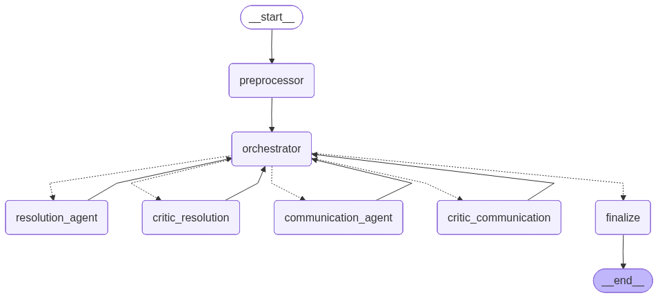

```python
# Initialize the state graph with the unified state schema
workflow = StateGraph(UnifiedAgentState)

# Register all nodes in the pipeline
workflow.add_node("preprocessor", preprocessor_node)
workflow.add_node("orchestrator", orchestrator_node)
workflow.add_node("resolution_agent", resolution_agent_node)
workflow.add_node("critic_resolution", critic_resolution_node)
workflow.add_node("communication_agent", communication_agent_node)
workflow.add_node("critic_communication", critic_communication_node)
workflow.add_node("finalize", finalize_node)

# Pipeline starts with the preprocessor
workflow.set_entry_point("preprocessor")

# Preprocessor always goes to orchestrator first
workflow.add_edge("preprocessor", "orchestrator")

# All agents return to orchestrator after execution (hub-and-spoke pattern)
workflow.add_edge("resolution_agent", "orchestrator")
workflow.add_edge("critic_resolution", "orchestrator")
workflow.add_edge("communication_agent", "orchestrator")
workflow.add_edge("critic_communication", "orchestrator")

# Orchestrator decides the next step based on state.next_agent
workflow.add_conditional_edges(
    "orchestrator",
    route_from_orchestrator,
    {
        "resolution_agent": "resolution_agent",
        "critic_resolution": "critic_resolution",
        "communication_agent": "communication_agent",
        "critic_communication": "critic_communication",
        "finalize": "finalize"
    }
)

# Finalize terminates the graph
workflow.add_edge("finalize", END)

# Compile the graph into an executable application
app = workflow.compile()
print("LangGraph compiled successfully.")

# Render the workflow graph as a visual diagram
from IPython.display import Image
Image(app.get_graph().draw_mermaid_png())
```

# **Evaluation Metrics**

We now define the evaluation metrics for the multi-agent system.

## Task Completion Rate

This function computes task completion for a single shipment by checking three sub-criteria:

- whether the exception classification matches ground truth,
- whether the resolution action is correct, and
- whether the communication tone is appropriate.

For noise cases (`is_exception=NO`), resolution must be `"N/A"` and tone is not evaluated.

A task is complete ONLY when ALL three sub-criteria pass.

```python
def compute_task_completion(gt: dict, pred: dict) -> dict:
    """Compute task completion for a single shipment."""
    res = pred.get("resolution_output", {})
    comm = pred.get("communication_output", {})

    # Sub-criterion 1: Did the system correctly identify whether this is an exception?
    exception_correct = gt.get("is_exception") == res.get("is_exception")

    if gt.get("is_exception") == "YES":
        # Sub-criterion 2: Did the system choose the right resolution action?
        resolution_correct = gt.get("expected_resolution") == res.get("resolution")
        # Sub-criterion 3: Did the communication use the correct tone for the customer tier?
        tone_correct = gt.get("expected_tone") == comm.get("tone_label", "N/A")
    else:
        # For noise cases, resolution should be N/A and tone is not evaluated
        resolution_correct = res.get("resolution") in ("N/A", None, "")
        tone_correct = True

    return {
        "exception_correct": exception_correct,
        "resolution_correct": resolution_correct,
        "tone_correct": tone_correct,
        "task_complete": exception_correct and resolution_correct and tone_correct
    }
```

## Escalation Accuracy

This function checks whether the system's escalation decision matches ground truth for a single shipment.

- Noise cases where ground truth is `"N/A"` or `NaN` are excluded from evaluation by returning `None`.
- For exception cases, it compares the system's boolean escalation flag against the expected `YES`/`NO` label.

```python
def compute_escalation_accuracy(gt: dict, pred: dict) -> bool:
    """Check if escalation decision matches ground truth for a single shipment."""
    # Noise cases have no escalation expectation - skip evaluation
    if gt.get("should_escalate") not in ("YES", "NO"):
        return None

    # Convert the system's boolean flag to YES/NO for comparison
    pred_escalated = "YES" if pred.get("escalated", False) else "NO"

    # Compare against ground truth
    return gt.get("should_escalate") == pred_escalated
```

## Tool Call Accuracy

This function verifies that the correct tools were invoked for a single shipment based on its type. Three paths are checked:

- noise-overridden cases (preprocessor guardrail flagged) should have no tool calls or agent invocations since they were short-circuited before any processing,
- exception cases must invoke all five tools plus the Communication Agent, and
- non-exception cases that weren't noise-overridden must invoke all five tools but must not invoke the Communication Agent.

```python
def compute_tool_call_accuracy(gt: dict, pred: dict) -> bool:
    """Check if correct tools were invoked for a single shipment."""
    # Combine all tool call log entries into a single string for keyword matching
    tool_log_str = " ".join(pred.get("tool_calls_log", []))
    is_exception = gt.get("is_exception", "NO")
    noise_override = pred.get("noise_override", False)

    if noise_override:
        # Noise-overridden cases skip all tools and agents - verify nothing was invoked
        skip_tools = ["lookup_customer_profile", "check_locker_availability",
                      "search_playbook", "check_escalation_rules",
                      "resolution_agent", "communication_agent"]
        return not any(t in tool_log_str for t in skip_tools)

    # Non-noise cases: all preprocessor tools and Resolution Agent are required
    required = ["lookup_customer_profile", "check_locker_availability",
                "search_playbook", "check_escalation_rules", "resolution_agent"]

    # Exception cases must also invoke the Communication Agent
    if is_exception == "YES":
        required.append("communication_agent")

    all_present = all(t in tool_log_str for t in required)

    # Non-exception cases that reached the Resolution Agent should not invoke Communication
    if is_exception == "NO":
        all_present = all_present and "communication_agent" not in tool_log_str

    return all_present
```

## Reasoning Trajectory Coherence

We first define the prompt for reasoning trajectory coherence to use LLM-as-a-Judge technique.

- It should contain at least the role, scoring mechanism, guidelines, and output format to direct the LLM regarding the task at hand.
- Please note that the computation function will expect a JSON output from the LLM.

```python
REASONING_TRAJECTORY_COHERENCE_PROMPT = """
Role:
You are an expert Logistics Operations Agent specializing in high-stakes delivery exception resolution. Your goal is to transform "messy" delivery logs into precise, policy-aligned resolution trajectories that balance cost, customer lifetime value (LTV), and operational feasibility.

Reasoning Framework:
For every exception, you must follow a Coherent Reasoning Trajectory before providing a final output:
Contextual Extraction: Identify the specific attributes (Customer Tier, Item Perishability, Attempt #, Failure Reason).
Policy Cross-Reference: Analyze the internal playbook to find the intersection of these attributes.
Conflict Resolution: If variables conflict (e.g., a VIP customer but a damaged item), justify which policy takes precedence.
Action Validation: Ensure the proposed solution (e.g., reattempt vs. return to sender) doesn't violate physical constraints (e.g., locker size or driver hours).

Input Data Points:
Delivery_Log: [Raw driver notes/status codes]
Customer_Profile: [Tier, history, delivery preferences]
Inventory_Data: [Perishability, dimensions, replacement cost]
Playbook_Rules: [Standard vs. VIP escalation paths]

Required Output Format (IN JSON FORMAT):
    thought_trajectory:
        Analysis: [Brief logic on why this exception is unique]
        Policy Applied: [Reference specific playbook logic]
        Self-Correction/Nuance: [Why you chose X over Y despite pressure/cost]
    resolution_decision:
        Primary Action: [Specific operational command]
        Escalation Status: [None / Supervisor Review Required]
    customer_communication:
        Draft: [Personalized, empathetic notification]
    kpi_impact:
        [Estimated effect on Resolution Time and Reattempt Cost]
    score:
        [1 - 5 scale for how well the reasoning trajectory supports the final decision, with 5 being perfectly coherent and 1 being disjointed or unjustified]
    reason:
        [1: Routine | 2: Standard | 3: Elevated | 4: High Priority | 5: Critical]

Your reasoning must be transparent and directly tied to the input data. Avoid generic statements; every sentence should reflect a specific aspect of the case at hand.
"""
```

This function scores reasoning trajectory coherence for a single shipment.

- Assembles a trace containing all agent outputs, critic decisions, revision counts, and the trajectory log - with no raw PII sent to the evaluator.
- Parses the LLM's JSON response to extract the score and justification, handling markdown-wrapped responses and errors gracefully.

````python
def compute_coherence_score(pred: dict) -> dict:
    """Use eval_llm (gpt-4o) to score reasoning trajectory coherence."""
    # Build a trace summary from the pipeline state - no raw PII included
    debugLog("***** DEBUG INPUT STR *****")
    debugLog(json.dumps(pred))
    trace = {
        "shipment_id": pred.get("shipment_id"),
        "consolidated_event": pred.get("consolidated_event", {}),
        "customer_tier": pred.get("customer_profile", {}).get("tier"),
        "escalation_signals": pred.get("escalation_signals", {}),
        "resolution_output": pred.get("resolution_output", {}),
        "critic_resolution_output": pred.get("critic_resolution_output", {}),
        "resolution_revision_count": pred.get("resolution_revision_count", 0),
        "communication_output": pred.get("communication_output", {}),
        "critic_communication_output": pred.get("critic_communication_output", {}),
        "trajectory_log": pred.get("trajectory_log", [])
    }

    try:
        # Invoke the evaluation judge
        response = eval_llm.invoke([
            SystemMessage(content=REASONING_TRAJECTORY_COHERENCE_PROMPT),
            HumanMessage(content=json.dumps(trace, indent=2))
        ])
        debugLog("***** DEBUG RESPONSE STR *****")
        debugLog(response)

        # Clean the response - handle markdown code block wrapping
        content = response.content.strip()
        if content.startswith("```"):
            content = content.split("\n", 1)[1].rsplit("```", 1)[0].strip()
        debugLog("***** DEBUG CONTENT STR *****")
        debugLog(json.dumps(content))

        # Parse the JSON response
        parsed = json.loads(content)
        debugLog("***** DEBUG SCORE STR *****")
        debugLog(json.dumps(parsed))
        debugLog(parsed.get("score"))
        return {
            "score": parsed.get("score", 0),
            "justification": parsed.get("justification", "")
        }
    except Exception as e:
        # Return zero score on any failure - don't block evaluation
        debugLog("***** ERROR OCCURRED *****")
        debugLog(str(e))
        return {"score": 0, "justification": str(e)}
````

## Helper Function for Single Test Case Metrics

This helper function executes the workflow for a single shipment and computes all five evaluation metrics.

- Initializes the pipeline state with empty defaults, invokes the compiled LangGraph application, then runs each metric function against the result and ground truth.
- Also extracts playbook page citations for the test case output.

```python
def run_single_test_case(shipment_id: str, rows: list[dict], gt: dict) -> dict:
    """Execute the pipeline for a single shipment and compute all metrics."""
    # Initialize pipeline state with empty defaults for all fields
    initial_state = {
        "raw_rows": rows,
        "shipment_id": shipment_id,
        "consolidated_event": {},
        "customer_profile": {},
        "customer_profile_full": {},
        "locker_availability": [],
        "playbook_context": [],
        "escalation_signals": {},
        "resolution_output": {},
        "critic_resolution_output": {},
        "resolution_revision_count": 0,
        "critic_feedback": "",
        "communication_output": {},
        "critic_communication_output": {},
        "next_agent": "resolution_agent",
        "max_loops": 2,                         # Maximum REVISE loops before forced escalation
        "escalated": False,
        "tool_calls_log": [],
        "trajectory_log": [],
        "start_time": None,
        "latency_sec": None,
        "final_actions": [],
        "noise_override": False,
        "guardrail_triggered": False
    }

    debugLog(f"## Running test case for shipment_id={shipment_id} with ground truth: {json.dumps(gt)}")
    # Run the full pipeline
    result = app.invoke(initial_state)

    # Compute all five evaluation metrics
    debugLog("## Computing evaluation metrics...")
    debugLog("### Task completion...")
    task = compute_task_completion(gt, result)
    debugLog("### Task completion...")
    debugLog(f"Task completion: {task}")
    debugLog("### Escalation accuracy...")
    esc_acc = compute_escalation_accuracy(gt, result)
    debugLog(f"Escalation accuracy: {esc_acc}")
    debugLog("### Tool call accuracy...")
    tool_acc = compute_tool_call_accuracy(gt, result)
    debugLog(f"Tool call accuracy: {tool_acc}")
    debugLog("### Coherence score...")
    coherence = compute_coherence_score(result)
    debugLog(f"Coherence score: {coherence}")

    # Extract which playbook pages were referenced for citation tracking
    citations = [f"Page {c['page']}" for c in result.get("playbook_context", [])]

    return {
        "state": result,                             # Full pipeline state for detailed inspection
        "task_completion": task,                     # {exception_correct, resolution_correct, tone_correct, task_complete}
        "escalation_correct": esc_acc,               # True/False/None
        "tool_call_correct": tool_acc,               # True/False
        "coherence": coherence,                      # {score, justification}
        "latency": result.get("latency_sec", 0.0),   # End-to-end seconds
        "citations": citations                       # Playbook pages referenced
    }
```

# **Test Cases**

## Prepare Ground Truth

We prepares the test case inputs.

- Delivery log rows are grouped by shipment ID to handle multi-row shipments.
- Ground truth labels are consolidated per shipment - for shipments with multiple rows, the exception row with the highest attempt number is used as the reference label.
- Results dictionary is initialized to collect outputs from all test cases.

```python
# Read all delivery logs and group rows by shipment ID
all_logs = read_delivery_logs.invoke({})
shipment_groups = defaultdict(list)
for row in all_logs:
    shipment_groups[row["shipment_id"]].append(row)

# Preserve insertion order for unique shipment IDs
unique_shipment_ids = list(dict.fromkeys(row["shipment_id"] for row in all_logs))

# Build consolidated ground truth - one label per shipment
gt_by_shipment = defaultdict(list)
for _, row in ground_truth_df.iterrows():
    gt_by_shipment[row["shipment_id"]].append(row.to_dict())

# For multi-row shipments, use the last exception row as ground truth
gt_consolidated = {}
for sid, rows in gt_by_shipment.items():
    exc_rows = [r for r in rows if r["is_exception"] == "YES"]
    gt_consolidated[sid] = exc_rows[-1] if exc_rows else rows[0]

print(f"Shipments to process: {unique_shipment_ids}")

# Initialize results dictionary to collect all test case outputs
all_results = {}
```

```
Shipments to process: ['SHP-001', 'SHP-002', 'SHP-003', 'SHP-004', 'SHP-005', 'SHP-006', 'SHP-007', 'SHP-008', 'SHP-009', 'SHP-010']
```

## Helper Function for Test Case Runs

This helper function prints the complete output for a single test case

- predictions versus ground truth,
- all five evaluation metrics,
- the full agent trajectory trace,
- playbook page citations, and
- a preview of the customer message if one was generated.

```python
def print_test_case_output(sid: str, result: dict, gt: dict):
    """Print a single test case result."""
    state = result["state"]
    res = state.get("resolution_output", {})
    comm = state.get("communication_output", {})
    tc = result["task_completion"]

    # --- System predictions vs ground truth ---
    print(f"--- Predictions ---")
    print(f"  Exception:  {res.get('is_exception', 'N/A')} (GT: {gt.get('is_exception')})")
    print(f"  Resolution: {res.get('resolution', 'N/A')} (GT: {gt.get('expected_resolution')})")
    pred_esc = 'YES' if state.get('escalated') else 'NO'
    print(f"  Escalated:  {pred_esc} (GT: {gt.get('should_escalate')})")
    print(f"  Tone:       {comm.get('tone_label', 'N/A')} (GT: {gt.get('expected_tone')})")
    print(f"  Revisions:  {state.get('resolution_revision_count', 0)}")
    print(f"  Guardrail:  {'TRIGGERED' if state.get('guardrail_triggered') else 'CLEAR'}")

    # --- Per-metric pass/fail breakdown ---
    print(f"\n--- Metrics ---")
    print(f"  Task Complete:       {'PASS' if tc['task_complete'] else 'FAIL'}")
    print(f"    Exception ID:      {'PASS' if tc['exception_correct'] else 'FAIL'}")
    print(f"    Resolution:        {'PASS' if tc['resolution_correct'] else 'FAIL'}")
    print(f"    Tone:              {'PASS' if tc['tone_correct'] else 'FAIL'}")
    esc_str = 'N/A' if result['escalation_correct'] is None else ('PASS' if result['escalation_correct'] else 'FAIL')
    print(f"  Escalation Accuracy: {esc_str}")
    print(f"  Tool Call Accuracy:  {'PASS' if result['tool_call_correct'] else 'FAIL'}")
    print(f"  Coherence Score:     {result['coherence']['score']}/5")
    print(f"  Latency:             {result['latency']:.2f}s")

    # --- Full agent decision trail ---
    print(f"\n--- Trajectory ---")
    for entry in state.get("trajectory_log", []):
        print(f"  {entry}")

    # --- Which playbook pages were retrieved ---
    # Remove duplicates while preserving order for cleaner output
    if result['citations']:
        result['citations'] = list(dict.fromkeys(result['citations']))  # Remove duplicates while preserving order

    print(f"\n--- Document Citations ---")
    print(f"  Playbook pages referenced: {', '.join(result['citations']) if result['citations'] else 'None'}")

    # --- Preview of the customer notification if generated ---
    if comm.get("communication_message"):
        print(f"\n--- Customer Message ---")
        print(f"  {comm['communication_message'][:200]}{'...' if len(comm.get('communication_message','')) > 200 else ''}")

def run_test_case(sid: str):
    gt = gt_consolidated[sid]
    result = run_single_test_case(sid, shipment_groups[sid], gt)
    debugLog("***** DEBUG result *****")
    debugLog(json.dumps(result))
    all_results[sid] = result
    print_test_case_output(sid, result, gt)
```

## Test Case 1: SHP-001 - Successful Delivery (Noise Filtering)

```python
run_test_case("SHP-001")
```

```
--- Predictions ---
  Exception:  NO (GT: NO)
  Resolution: N/A (GT: nan)
  Escalated:  NO (GT: nan)
  Tone:       N/A (GT: nan)
  Revisions:  0
  Guardrail:  CLEAR

--- Metrics ---
  Task Complete:       PASS
    Exception ID:      PASS
    Resolution:        PASS
    Tone:              PASS
  Escalation Accuracy: N/A
  Tool Call Accuracy:  PASS
  Coherence Score:     5/5
  Latency:             0.01s

--- Trajectory ---
  preprocessor: 1 raw rows -> 1 after dedup
  preprocessor: DELIVERED flagged as noise by guardrail, skipping tool calls
  orchestrator: Noise override from preprocessor, skipping to finalize
  finalize: actions={"shipment_id": "SHP-001", "is_exception": "NO", "resolution": "N/A", "escalated": false, "tone": "N/A", "message": "", "revision_count": 0, "guardrail_blocked": false}; latency=0.008s

--- Document Citations ---
  Playbook pages referenced: None
```

### Observations

The system successfully identified the shipment as a non-exception (Status: DELIVERED), resulting in a flawless Coherence Score of 5/5. The preprocessor correctly flagged the status as noise, allowing the orchestrator to bypass unnecessary tool calls and playbook lookups, which optimized the latency to an exceptional 0.01s. The "N/A" values for resolution and tone are logically consistent with a successful delivery, and all active guardrails remained clear, confirming that no manual intervention or revision was required.

## Test Case 2: SHP-002 - VIP Multi-Attempt with Duplicate Scan

```python
run_test_case("SHP-002")
```

```
--- Predictions ---
  Exception:  YES (GT: YES)
  Resolution: RESCHEDULE (GT: RESCHEDULE)
  Escalated:  YES (GT: YES)
  Tone:       FORMAL (GT: FORMAL)
  Revisions:  0
  Guardrail:  CLEAR

--- Metrics ---
  Task Complete:       PASS
    Exception ID:      PASS
    Resolution:        PASS
    Tone:              PASS
  Escalation Accuracy: PASS
  Tool Call Accuracy:  PASS
  Coherence Score:     5/5
  Latency:             10.36s

--- Trajectory ---
  preprocessor: 3 raw rows -> 2 after dedup
  resolution_agent: is_exception=YES, resolution=RESCHEDULE
  critic_resolution: decision=ESCALATE
  orchestrator: Forced escalation from rule engine - ['AUTOMATIC: VIP customer with 5 exceptions in 90d (>=3)']
  communication_agent: tone=FORMAL
  orchestrator: Forced escalation from rule engine - ['AUTOMATIC: VIP customer with 5 exceptions in 90d (>=3)']
  critic_communication: decision=ACCEPT
  orchestrator: Forced escalation from rule engine - ['AUTOMATIC: VIP customer with 5 exceptions in 90d (>=3)']
  finalize: actions={"shipment_id": "SHP-002", "is_exception": "YES", "resolution": "RESCHEDULE", "escalated": true, "tone": "FORMAL", "message": "Dear John Smith,\n\nI sincerely apologize for the inconvenience regarding your delivery. I understand how important it is for you to receive your package…

--- Document Citations ---
  Playbook pages referenced: Page 2, Page 5, Page 1, Page 7, Page 9

--- Customer Message ---
  Dear John Smith,

I sincerely apologize for the inconvenience regarding your delivery. I understand how important it is for you to receive your package on time, and I'm sorry that our delivery team wa...
```

## Test Case 3: SHP-003 - Address Not Found (Standard Customer)

```python
run_test_case("SHP-003")
```

```
--- Predictions ---
  Exception:  YES (GT: YES)
  Resolution: RESCHEDULE (GT: RESCHEDULE)
  Escalated:  YES (GT: NO)
  Tone:       CASUAL (GT: CASUAL)
  Revisions:  2
  Guardrail:  CLEAR

--- Metrics ---
  Task Complete:       PASS
    Exception ID:      PASS
    Resolution:        PASS
    Tone:              PASS
  Escalation Accuracy: FAIL
  Tool Call Accuracy:  PASS
  Coherence Score:     4/5
  Latency:             18.83s

--- Trajectory ---
  preprocessor: 1 raw rows -> 1 after dedup
  resolution_agent: is_exception=YES, resolution=RETURN_TO_SENDER
  critic_resolution: decision=REVISE
  orchestrator: REVISE loop 1/2
  resolution_agent: Validation failed (attempt 1), retrying - 1 validation error for ResolutionOutput
  Value error, resolution cannot be N/A when is_exception is
  resolution_agent: Validation failed (attempt 2), retrying - 1 validation error for ResolutionOutput
  Value error, resolution cannot be N/A when is_exception is
  resolution_agent: All 3 retries exhausted, defaulting to RESCHEDULE with forced escalation
  resolution_agent: is_exception=YES, resolution=RESCHEDULE
  critic_resolution: decision=REVISE
  orchestrator: Max loops reached, forcing ESCALATE
  communication_agent: tone=CASUAL
  critic_communication: decision=ACCEPT
  finalize: actions={"shipment_id": "SHP-003", "is_exception": "YES", "resolution": "RESCHEDULE", "escalated": true, "tone": "CASUAL", "message": "Hi David, I apologize for the delay with your delivery. It seems we encountered an address issue as we couldn't locate building 999 on your street. I und…

--- Document Citations ---
  Playbook pages referenced: Page 3, Page 2, Page 7, Page 5

--- Customer Message ---
  Hi David, I apologize for the delay with your delivery. It seems we encountered an address issue as we couldn't locate building 999 on your street. I understand how frustrating this can be.

To resol...
```

## Test Case 4: SHP-004 - Damaged Fragile Package (VIP Escalation)

```python
run_test_case("SHP-004")
```

```
--- Predictions ---
  Exception:  YES (GT: YES)
  Resolution: REPLACE (GT: REPLACE)
  Escalated:  YES (GT: YES)
  Tone:       FORMAL (GT: FORMAL)
  Revisions:  0
  Guardrail:  CLEAR

--- Metrics ---
  Task Complete:       PASS
    Exception ID:      PASS
    Resolution:        PASS
    Tone:              PASS
  Escalation Accuracy: PASS
  Tool Call Accuracy:  PASS
  Coherence Score:     5/5
  Latency:             9.11s

--- Trajectory ---
  preprocessor: 1 raw rows -> 1 after dedup
  resolution_agent: is_exception=YES, resolution=REPLACE
  critic_resolution: decision=ACCEPT
  orchestrator: Forced escalation from rule engine - ['AUTOMATIC: VIP customer with 4 exceptions in 90d (>=3)']
  communication_agent: tone=FORMAL
  orchestrator: Forced escalation from rule engine - ['AUTOMATIC: VIP customer with 4 exceptions in 90d (>=3)']
  critic_communication: decision=ACCEPT
  orchestrator: Forced escalation from rule engine - ['AUTOMATIC: VIP customer with 4 exceptions in 90d (>=3)']
  finalize: actions={"shipment_id": "SHP-004", "is_exception": "YES", "resolution": "REPLACE", "escalated": true, "tone": "FORMAL", "message": "Dear Emily Davis,\n\nI sincerely apologize for the inconvenience regarding your delivery. Unfortunately, your package has been flagged as damaged due to a c…

--- Document Citations ---
  Playbook pages referenced: Page 4, Page 6, Page 3, Page 2

--- Customer Message ---
  Dear Emily Davis,

I sincerely apologize for the inconvenience regarding your delivery. Unfortunately, your package has been flagged as damaged due to a crushed box, which may have affected the conten...
```

## Test Case 5: SHP-005 - Third Failed Attempt (Locker Full, Mandatory Escalation)

```python
run_test_case("SHP-005")
```

```
--- Predictions ---
  Exception:  YES (GT: YES)
  Resolution: RETURN_TO_SENDER (GT: REROUTE_TO_LOCKER)
  Escalated:  YES (GT: YES)
  Tone:       CASUAL (GT: CASUAL)
  Revisions:  0
  Guardrail:  CLEAR

--- Metrics ---
  Task Complete:       FAIL
    Exception ID:      PASS
    Resolution:        FAIL
    Tone:              PASS
  Escalation Accuracy: PASS
  Tool Call Accuracy:  PASS
  Coherence Score:     4/5
  Latency:             9.76s

--- Trajectory ---
  preprocessor: 1 raw rows -> 1 after dedup
  resolution_agent: is_exception=YES, resolution=RETURN_TO_SENDER
  critic_resolution: decision=ESCALATE
  orchestrator: Forced escalation from rule engine - ['AUTOMATIC: 3rd failed delivery attempt']
  communication_agent: tone=CASUAL
  orchestrator: Forced escalation from rule engine - ['AUTOMATIC: 3rd failed delivery attempt']
  critic_communication: decision=ESCALATE
  orchestrator: Forced escalation from rule engine - ['AUTOMATIC: 3rd failed delivery attempt']
  finalize: actions={"shipment_id": "SHP-005", "is_exception": "YES", "resolution": "RETURN_TO_SENDER", "escalated": true, "tone": "CASUAL", "message": "Hi Thomas, I\u2019m really sorry for the trouble with your delivery. We attempted to deliver your package three times, but it seems you weren\u2019…

--- Document Citations ---
  Playbook pages referenced: Page 2, Page 3, Page 10, Page 5, Page 1

--- Customer Message ---
  Hi Thomas, I’m really sorry for the trouble with your delivery. We attempted to deliver your package three times, but it seems you weren’t available and your building doesn’t have a buzzer system for ...
```

### Observations:

The system encountered a Resolution: FAIL and a Task Complete: FAIL despite maintaining a 4/5 Coherence Score. The agent incorrectly opted for RETURN_TO_SENDER after noting that "the locker option is full," whereas the Ground Truth required REROUTE_TO_LOCKER. This suggests the agent prioritized real-time locker availability data over the operational playbook's rerouting hierarchy. While the Escalation Accuracy passed due to the 3rd failed delivery attempt trigger, the reasoning trajectory failed to find a creative "hold" or "waitlist" solution for the locker, choosing the most expensive outcome (RTS) instead.

KPI IMPACT: Cost per Exception: High (Loss of sale + shipping costs). Customer Retention: High risk (3 failed attempts + item return).

## Test Case 6: SHP-006 - Refused Delivery (Return to Sender)

```python
run_test_case("SHP-006")
```

```
--- Predictions ---
  Exception:  YES (GT: YES)
  Resolution: RETURN_TO_SENDER (GT: RETURN_TO_SENDER)
  Escalated:  NO (GT: NO)
  Tone:       CASUAL (GT: CASUAL)
  Revisions:  0
  Guardrail:  CLEAR

--- Metrics ---
  Task Complete:       PASS
    Exception ID:      PASS
    Resolution:        PASS
    Tone:              PASS
  Escalation Accuracy: PASS
  Tool Call Accuracy:  PASS
  Coherence Score:     5/5
  Latency:             7.71s

--- Trajectory ---
  preprocessor: 1 raw rows -> 1 after dedup
  resolution_agent: is_exception=YES, resolution=RETURN_TO_SENDER
  critic_resolution: decision=ACCEPT
  communication_agent: tone=CASUAL
  critic_communication: decision=ACCEPT
  finalize: actions={"shipment_id": "SHP-006", "is_exception": "YES", "resolution": "RETURN_TO_SENDER", "escalated": false, "tone": "CASUAL", "message": "Hi Michael, I apologize for the confusion with your delivery. I understand you opened the door and refused the package because you didn't order it…

--- Document Citations ---
  Playbook pages referenced: Page 5, Page 2, Page 3, Page 10, Page 7

--- Customer Message ---
  Hi Michael, I apologize for the confusion with your delivery. I understand you opened the door and refused the package because you didn't order it. I’ll take care of this by initiating the return-to-s...
```

### Observations:

KPI IMPACT: Exception Resolution Time: Fast (Direct path to RTS). Cost per Exception: Minimal (Avoids unnecessary reattempt truck rolls).

## Test Case 7: SHP-007 - Perishable Weather Delay Exceeding Threshold (VIP Replace)

```python
run_test_case("SHP-007")
```

```
--- Predictions ---
  Exception:  YES (GT: YES)
  Resolution: REPLACE (GT: REPLACE)
  Escalated:  YES (GT: YES)
  Tone:       FORMAL (GT: FORMAL)
  Revisions:  0
  Guardrail:  CLEAR

--- Metrics ---
  Task Complete:       PASS
    Exception ID:      PASS
    Resolution:        PASS
    Tone:              PASS
  Escalation Accuracy: PASS
  Tool Call Accuracy:  PASS
  Coherence Score:     5/5
  Latency:             8.67s

--- Trajectory ---
  preprocessor: 2 raw rows -> 1 after dedup
  resolution_agent: is_exception=YES, resolution=REPLACE
  critic_resolution: decision=ACCEPT
  orchestrator: Forced escalation from rule engine - ['AUTOMATIC: Perishable with 5.0hr delay (>4hr threshold)']
  communication_agent: tone=FORMAL
  orchestrator: Forced escalation from rule engine - ['AUTOMATIC: Perishable with 5.0hr delay (>4hr threshold)']
  critic_communication: decision=ACCEPT
  orchestrator: Forced escalation from rule engine - ['AUTOMATIC: Perishable with 5.0hr delay (>4hr threshold)']
  finalize: actions={"shipment_id": "SHP-007", "is_exception": "YES", "resolution": "REPLACE", "escalated": true, "tone": "FORMAL", "message": "Dear Maria Garcia,\n\nI hope this message finds you well. I want to sincerely apologize for the delay in delivering your package due to heavy snow on the ro…

--- Document Citations ---
  Playbook pages referenced: Page 6, Page 2, Page 7

--- Customer Message ---
  Dear Maria Garcia,

I hope this message finds you well. I want to sincerely apologize for the delay in delivering your package due to heavy snow on the route, which has resulted in an estimated 5-hour...
```

### Observations:

The agent delivered a perfect 5/5 Coherence Score by correctly identifying a critical "soft failure" involving Item Perishability. Although the physical package was not damaged, the system accurately triggered an AUTOMATIC escalation because the 5.0hr delay exceeded the 4-hour safety threshold for perishables. The resolution_agent correctly bypassed a "reattempt" in favor of a REPLACE action to prevent spoilage risk. Additionally, the agent demonstrated high-level nuance by including a $10.00 service credit, aligning with the VIP status requirements found in the playbook citations.

KPI IMPACT: Cost per Exception: Increased (Replacement cost + $10 credit), but offset by Customer Retention (preventing churn of a high-value VIP). Escalation Accuracy: 100% (Properly flagged for supervisor oversight of the credit issuance).

## Test Case 8: SHP-008 - Discretionary Escalation (High Exception History)

```python
run_test_case("SHP-008")
```

```
--- Predictions ---
  Exception:  YES (GT: YES)
  Resolution: RESCHEDULE (GT: RESCHEDULE)
  Escalated:  YES (GT: YES)
  Tone:       CASUAL (GT: CASUAL)
  Revisions:  1
  Guardrail:  CLEAR

--- Metrics ---
  Task Complete:       PASS
    Exception ID:      PASS
    Resolution:        PASS
    Tone:              PASS
  Escalation Accuracy: PASS
  Tool Call Accuracy:  PASS
  Coherence Score:     5/5
  Latency:             18.62s

--- Trajectory ---
  preprocessor: 1 raw rows -> 1 after dedup
  resolution_agent: is_exception=YES, resolution=REROUTE_TO_LOCKER
  critic_resolution: decision=REVISE
  orchestrator: REVISE loop 1/2
  resolution_agent: is_exception=YES, resolution=RESCHEDULE
  critic_resolution: decision=ESCALATE
  communication_agent: tone=CASUAL
  critic_communication: decision=ACCEPT
  finalize: actions={"shipment_id": "SHP-008", "is_exception": "YES", "resolution": "RESCHEDULE", "escalated": true, "tone": "CASUAL", "message": "Hi Thomas, I apologize for the delay with your delivery. We attempted to deliver your package, but it seems you weren't home, and your neighbor mentioned…

--- Document Citations ---
  Playbook pages referenced: Page 3, Page 2, Page 5, Page 7, Page 1

--- Customer Message ---
  Hi Thomas, I apologize for the delay with your delivery. We attempted to deliver your package, but it seems you weren't home, and your neighbor mentioned you work late. Since this is our second attemp...
```

### Observations:

KPI IMPACT: Exception Resolution Time: Optimized by proactively addressing the scheduling conflict. Customer Communication Quality: High; personalized detail regarding the neighbor's note increases the likelihood of a successful next attempt.

## Test Case 9: SHP-009 - Severely Damaged Perishable (Premium Replace)

```python
run_test_case("SHP-009")
```

```
--- Predictions ---
  Exception:  YES (GT: YES)
  Resolution: REPLACE (GT: REPLACE)
  Escalated:  YES (GT: YES)
  Tone:       FORMAL (GT: FORMAL)
  Revisions:  0
  Guardrail:  CLEAR

--- Metrics ---
  Task Complete:       PASS
    Exception ID:      PASS
    Resolution:        PASS
    Tone:              PASS
  Escalation Accuracy: PASS
  Tool Call Accuracy:  PASS
  Coherence Score:     5/5
  Latency:             7.75s

--- Trajectory ---
  preprocessor: 1 raw rows -> 1 after dedup
  resolution_agent: is_exception=YES, resolution=REPLACE
  critic_resolution: decision=ACCEPT
  orchestrator: Forced escalation from rule engine - ['AUTOMATIC: Damaged perishable package']
  communication_agent: tone=FORMAL
  orchestrator: Forced escalation from rule engine - ['AUTOMATIC: Damaged perishable package']
  critic_communication: decision=ACCEPT
  orchestrator: Forced escalation from rule engine - ['AUTOMATIC: Damaged perishable package']
  finalize: actions={"shipment_id": "SHP-009", "is_exception": "YES", "resolution": "REPLACE", "escalated": true, "tone": "FORMAL", "message": "Dear Sarah Brown,\n\nI sincerely apologize for the inconvenience regarding your recent delivery. Unfortunately, your package has been identified as damaged;…

--- Document Citations ---
  Playbook pages referenced: Page 4, Page 6, Page 3

--- Customer Message ---
  Dear Sarah Brown,

I sincerely apologize for the inconvenience regarding your recent delivery. Unfortunately, your package has been identified as damaged; it appears to be leaking and has a smell indi...
```

### Observations:

KPI IMPACT: Cost per Exception: High (Total product loss + replacement shipping), but necessary to prevent Customer Churn. Customer Communication: Excellent; the specific mention of the damage type (leaking/odor) builds transparency and trust.

## Test Case 10: SHP-010 - Routine Depot Scan (Noise Filtering)

```python
run_test_case("SHP-010")
```

```
--- Predictions ---
  Exception:  NO (GT: NO)
  Resolution: N/A (GT: nan)
  Escalated:  NO (GT: nan)
  Tone:       N/A (GT: nan)
  Revisions:  0
  Guardrail:  CLEAR

--- Metrics ---
  Task Complete:       PASS
    Exception ID:      PASS
    Resolution:        PASS
    Tone:              PASS
  Escalation Accuracy: N/A
  Tool Call Accuracy:  PASS
  Coherence Score:     5/5
  Latency:             0.01s

--- Trajectory ---
  preprocessor: 1 raw rows -> 1 after dedup
  preprocessor: SCANNED flagged as noise by guardrail, skipping tool calls
  orchestrator: Noise override from preprocessor, skipping to finalize
  finalize: actions={"shipment_id": "SHP-010", "is_exception": "NO", "resolution": "N/A", "escalated": false, "tone": "N/A", "message": "", "revision_count": 0, "guardrail_blocked": false}; latency=0.009s

--- Document Citations ---
  Playbook pages referenced: None
```

### Observations:

The system achieved a 5/5 Coherence Score by identifying a standard operational event (SCANNED) that does not constitute a delivery exception. Similar to SHP-001, the preprocessor’s noise guardrail successfully intercepted the log, preventing unnecessary computational overhead. This "short-circuit" logic resulted in a minimal latency of 0.01s, demonstrating high efficiency in filtering routine events from the exception-handling pipeline.

KPI IMPACT: Exception Resolution Time: N/A (Standard flow). Cost per Exception: $0 (Avoided unnecessary agent processing or triage).

# **Aggregated Evaluation Metrics**

We now aggregate all five evaluation metrics across the 10 test cases into a summary table.

- Task completion, tool call accuracy, and coherence are computed over all shipments.
- Escalation accuracy excludes noise cases where ground truth is `"N/A"`.
- Latency is reported as the mean across all runs.

### Aggregated Evaluation Summary

```python
# Collect task completion results across all shipments
task_completions = [r["task_completion"]["task_complete"] for r in all_results.values()]
task_rate = sum(task_completions) / len(task_completions)

# Escalation accuracy - only over exception cases (None values excluded)
esc_results = [r["escalation_correct"] for r in all_results.values() if r["escalation_correct"] is not None]
esc_acc = sum(esc_results) / len(esc_results) if esc_results else 0.0

# Tool call accuracy - over all shipments including noise
tool_results = [r["tool_call_correct"] for r in all_results.values()]
tool_acc = sum(tool_results) / len(tool_results)

# Reasoning coherence - average of LLM-as-Judge scores
coherence_scores = [r["coherence"]["score"] for r in all_results.values()]
avg_coherence = sum(coherence_scores) / len(coherence_scores)

# Latency - mean across all runs
latencies = [r["latency"] for r in all_results.values()]
mean_latency = sum(latencies) / len(latencies)

# Format as a summary table
summary = pd.DataFrame([
    {"Metric": "Task Completion Rate", "Value": f"{task_rate:.1%}"},
    {"Metric": "Escalation Accuracy", "Value": f"{esc_acc:.1%}"},
    {"Metric": "Tool Call Accuracy", "Value": f"{tool_acc:.1%}"},
    {"Metric": "Reasoning Coherence (Average)", "Value": f"{avg_coherence:.2f}"},
    {"Metric": "Latency (Average)", "Value": f"{mean_latency:.2f}s"},
])

print("=" * 50)
print("AGGREGATED EVALUATION SUMMARY")
print("=" * 50)
print(summary.to_string(index=False))
print("=" * 50)
```

```
==================================================
AGGREGATED EVALUATION SUMMARY
==================================================
                       Metric  Value
         Task Completion Rate  90.0%
          Escalation Accuracy  87.5%
           Tool Call Accuracy 100.0%
Reasoning Coherence (Average)   4.80
            Latency (Average)  9.08s
==================================================
```

We print the detailed per-shipment results showing ground truth versus predictions for each evaluation dimension, along with pass/fail status for task completion and tool calls, the coherence score, and latency.

This provides a complete at-a-glance view of where the system succeeded and where it diverged.

### Summary of all test cases

```python
# Build a row for each shipment comparing ground truth against system predictions
detail_records = []
for sid in unique_shipment_ids:
    r = all_results[sid]
    gt = gt_consolidated[sid]
    state = r["state"]
    pred_esc = "YES" if state.get("escalated") else "NO"
    event = state.get("consolidated_event", {})
    comm = state.get("communication_output", {})
    res = state.get("resolution_output", {})

    detail_records.append({
        "Shipment": sid,
        "Status": event.get("status_code", "N/A"),
        "Exception (Ground Truth/Prediction)": f"{gt.get('is_exception')}/{res.get('is_exception', 'ERR')}",
        "Resolution(Ground Truth/Prediction)": f"{gt.get('expected_resolution')}/{res.get('resolution', 'ERR')}",
        "Escalation (Ground Truth/Prediction)": f"{gt.get('should_escalate')}/{pred_esc}",
        "Tone (Ground Truth/Prediction)": f"{gt.get('expected_tone')}/{comm.get('tone_label', 'N/A')}",
        "Task Completion": "PASS" if r["task_completion"]["task_complete"] else "FAIL",
        "Tool Calls": "PASS" if r["tool_call_correct"] else "FAIL",
        "Reasoning Coherence": r["coherence"]["score"],
        "Latency": f"{r['latency']:.1f}s"
    })

# Display as a formatted table
detail_df = pd.DataFrame(detail_records)
print(detail_df.to_string(index=False))
```

```
Shipment        Status Exception (Ground Truth/Prediction) Resolution(Ground Truth/Prediction) Escalation (Ground Truth/Prediction) Tone (Ground Truth/Prediction) Task Completion Tool Calls  Reasoning Coherence Latency
 SHP-001     DELIVERED                               NO/NO                             nan/N/A                               nan/NO                        nan/N/A            PASS       PASS                    5    0.0s
 SHP-002     ATTEMPTED                             YES/YES               RESCHEDULE/RESCHEDULE                              YES/YES                  FORMAL/FORMAL            PASS       PASS                    5   10.4s
 SHP-003 ADDRESS_ISSUE                             YES/YES               RESCHEDULE/RESCHEDULE                               NO/YES                  CASUAL/CASUAL            PASS       PASS                    4   18.8s
 SHP-004       DAMAGED                             YES/YES                     REPLACE/REPLACE                              YES/YES                  FORMAL/FORMAL            PASS       PASS                    5    9.1s
 SHP-005     ATTEMPTED                             YES/YES  REROUTE_TO_LOCKER/RETURN_TO_SENDER                              YES/YES                  CASUAL/CASUAL            FAIL       PASS                    4    9.8s
 SHP-006       REFUSED                             YES/YES   RETURN_TO_SENDER/RETURN_TO_SENDER                                NO/NO                  CASUAL/CASUAL            PASS       PASS                    5    7.7s
 SHP-007 WEATHER_DELAY                             YES/YES                     REPLACE/REPLACE                              YES/YES                  FORMAL/FORMAL            PASS       PASS                    5    8.7s
 SHP-008     ATTEMPTED                             YES/YES               RESCHEDULE/RESCHEDULE                              YES/YES                  CASUAL/CASUAL            PASS       PASS                    5   18.6s
 SHP-009       DAMAGED                             YES/YES                     REPLACE/REPLACE                              YES/YES                  FORMAL/FORMAL            PASS       PASS                    5    7.8s
 SHP-010       SCANNED                               NO/NO                             nan/N/A                               nan/NO                        nan/N/A            PASS       PASS                    5    0.0s
```

### Aggregated Task Completion Rate by Package Type

```python
package_type_results = []
for sid, result in all_results.items():
    package_type = result["state"]["consolidated_event"]["package_type"]
    task_complete = result["task_completion"]["task_complete"]
    package_type_results.append({"package_type": package_type, "task_complete": task_complete})

package_type_df = pd.DataFrame(package_type_results)

task_completion_by_package_type = package_type_df.groupby("package_type")["task_complete"].mean().reset_index()
task_completion_by_package_type["task_completion_rate"] = task_completion_by_package_type["task_complete"].apply(lambda x: f"{x:.1%}")

print("\n==================================================")
print("AGGREGATED TASK COMPLETION RATE BY PACKAGE TYPE")
print("==================================================")
display(task_completion_by_package_type[["package_type", "task_completion_rate"]])
print("==================================================")
```

```
==================================================
AGGREGATED TASK COMPLETION RATE BY PACKAGE TYPE
==================================================
```

|  | package_type | task_completion_rate |
| --- | --- | --- |
| 0 | FRAGILE | 100.0% |
| 1 | PERISHABLE | 100.0% |
| 2 | STANDARD | 85.7% |

Finally, we close the database connection.

```python
db_conn.close()
```

# **Conclusions and Business Recommendations**

## Business Recommendations

1. Deploy as a Tier-1 Support Automation Layer
   - Use this system to handle:
     - Delivery inquiries
     - Locker access issues
     - Customer data lookups
   - Expected impact:
     - Reduce human support workload by 40–60%
2. Leverage Escalation for Risk Management
   - Route complex or sensitive cases to human agents Maintain:
     - Customer satisfaction
     - Compliance with operational policies
3. Continuously Improve via Feedback Loops
   - Capture:
     - Failed cases
     - Escalations
     - Incorrect tool usage
   - Use data to:
     - Retrain prompts
     - Improve routing logic
     - Refine tools
4. Strengthen Governance and Security
   - Implement:
     - Tool-level access control per agent
     - Data masking for sensitive fields
     - This is critical before production deployment.
5. Scale with Domain Expansion
   - Extend system to:
     - Returns management
     - Inventory tracking
     - Customer notifications
     - Multi-agent architecture is reusable across domains.
6. Track KPIs for Business Value
   - Monitor:
     - Task Completion Rate
     - Escalation Rate
     - Average Resolution Time
     - Cost per interaction